# PROBLEM STATEMENT

The objective is to predict bike rental usage based on inputs such as temperature, humidity, wind speed, etc.

This is my first project in which I will build a multi-layer perceptron network.

[output not shown]

- Data Reference:
  - Hadi Fanaee-T
  - Laboratory of Artificial Intelligence and Decision Support (LIAAD), University of Porto INESC Porto, Campus da FEUP Rua Dr. Roberto Frias, 378 4200 - 465 Porto, Portugal
  - https://archive.ics.uci.edu/ml/datasets/bike%2Bsharing%2Bdataset
- Data Description:
  - instant: record index
  - dteday : date
  - season : season (1:springer, 2:summer, 3:fall, 4:winter)
  - yr : year (0: 2011, 1:2012)
  - mnth : month ( 1 to 12)
  - hr : hour (0 to 23)
  - holiday : wether day is holiday or not (extracted from http://dchr.dc.gov/page/holiday-schedule)
  - weekday : day of the week
  - workingday : if day is neither weekend nor holiday is 1, otherwise is 0.
  - weathersit :
    - 1: Clear, Few clouds, Partly cloudy
    - 2: Mist + Cloudy, Mist + Broken clouds, Mist + Few clouds, Mist
    - 3: Light Snow, Light Rain + Thunderstorm + Scattered clouds, Light Rain + Scattered clouds
    - 4: Heavy Rain + Ice Pallets + Thunderstorm + Mist, Snow + Fog
  - temp : Normalized temperature in Celsius. The values are divided to 41 (max)
  - hum: Normalized humidity. The values are divided to 100 (max)
  - windspeed: Normalized wind speed. The values are divided to 67 (max)
  - casual: count of casual users
  - registered: count of registered users
  - cnt: count of total rental bikes including both casual and registered

Note: In this project we will only examine the *total rental count* as output.

I will revisit this project at some point to predict casual and registered separately.

# IMPORT LIBRARIES

```python
!pip install tensorflow-gpu==2.0.0.alpha0
import tensorflow as tf
import pandas as pd
import numpy as np
import seaborn as sns
import matplotlib.pyplot as plt
```

```
     |████████████████████████████████| 332.1MB 64kB/s
     |████████████████████████████████| 419kB 41.5MB/s
     |████████████████████████████████| 3.0MB 56.8MB/s
```

# IMPORT DATASETS

```python
# You will need to mount your drive using the following commands:
# For more information regarding mounting, please check this out: https://stackoverflow.com/questions/46986398/import-data-into-google-colaboratory

from google.colab import drive
drive.mount('/content/drive')
```

```
Go to this URL in a browser: https://accounts.google.com/o/oauth2/auth?client_id=947318989803-6bn6qk8qdgf4n4g3pfee6491hc0brc4i.apps.googleusercontent.com&redirect_uri=urn%3Aietf%3Awg%3Aoauth%3A2.0%3Aoob&scope=email%20https%3A%2F%2Fwww.googleapis.com%2Fauth%2Fdocs.test%20https%3A%2F%2Fwww.googleapis.…

Enter your authorization code:
··········
```

```python
# You have to include the full link to the csv file containing your dataset
bike = pd.read_csv('/content/drive/My Drive/Colab Notebooks/bike-sharing-daily.csv')
```

```python
bike
```

|  | instant | dteday | season | yr | mnth | holiday | weekday | workingday | weathersit | temp | hum | windspeed | casual | registered | cnt |
| --- | --- | --- | --- | --- | --- | --- | --- | --- | --- | --- | --- | --- | --- | --- | --- |
| 0 | 1 | 1/1/2011 | 1 | 0 | 1 | 0 | 6 | 0 | 2 | 0.344167 | 0.805833 | 0.160446 | 331 | 654 | 985 |
| 1 | 2 | 1/2/2011 | 1 | 0 | 1 | 0 | 0 | 0 | 2 | 0.363478 | 0.696087 | 0.248539 | 131 | 670 | 801 |
| 2 | 3 | 1/3/2011 | 1 | 0 | 1 | 0 | 1 | 1 | 1 | 0.196364 | 0.437273 | 0.248309 | 120 | 1229 | 1349 |
| 3 | 4 | 1/4/2011 | 1 | 0 | 1 | 0 | 2 | 1 | 1 | 0.200000 | 0.590435 | 0.160296 | 108 | 1454 | 1562 |
| 4 | 5 | 1/5/2011 | 1 | 0 | 1 | 0 | 3 | 1 | 1 | 0.226957 | 0.436957 | 0.186900 | 82 | 1518 | 1600 |
| 5 | 6 | 1/6/2011 | 1 | 0 | 1 | 0 | 4 | 1 | 1 | 0.204348 | 0.518261 | 0.089565 | 88 | 1518 | 1606 |
| 6 | 7 | 1/7/2011 | 1 | 0 | 1 | 0 | 5 | 1 | 2 | 0.196522 | 0.498696 | 0.168726 | 148 | 1362 | 1510 |
| 7 | 8 | 1/8/2011 | 1 | 0 | 1 | 0 | 6 | 0 | 2 | 0.165000 | 0.535833 | 0.266804 | 68 | 891 | 959 |
| 8 | 9 | 1/9/2011 | 1 | 0 | 1 | 0 | 0 | 0 | 1 | 0.138333 | 0.434167 | 0.361950 | 54 | 768 | 822 |
| 9 | 10 | 1/10/2011 | 1 | 0 | 1 | 0 | 1 | 1 | 1 | 0.150833 | 0.482917 | 0.223267 | 41 | 1280 | 1321 |
| 10 | 11 | 1/11/2011 | 1 | 0 | 1 | 0 | 2 | 1 | 2 | 0.169091 | 0.686364 | 0.122132 | 43 | 1220 | 1263 |
| 11 | 12 | 1/12/2011 | 1 | 0 | 1 | 0 | 3 | 1 | 1 | 0.172727 | 0.599545 | 0.304627 | 25 | 1137 | 1162 |
| 12 | 13 | 1/13/2011 | 1 | 0 | 1 | 0 | 4 | 1 | 1 | 0.165000 | 0.470417 | 0.301000 | 38 | 1368 | 1406 |
| 13 | 14 | 1/14/2011 | 1 | 0 | 1 | 0 | 5 | 1 | 1 | 0.160870 | 0.537826 | 0.126548 | 54 | 1367 | 1421 |
| 14 | 15 | 1/15/2011 | 1 | 0 | 1 | 0 | 6 | 0 | 2 | 0.233333 | 0.498750 | 0.157963 | 222 | 1026 | 1248 |
| 15 | 16 | 1/16/2011 | 1 | 0 | 1 | 0 | 0 | 0 | 1 | 0.231667 | 0.483750 | 0.188433 | 251 | 953 | 1204 |
| 16 | 17 | 1/17/2011 | 1 | 0 | 1 | 1 | 1 | 0 | 2 | 0.175833 | 0.537500 | 0.194017 | 117 | 883 | 1000 |
| 17 | 18 | 1/18/2011 | 1 | 0 | 1 | 0 | 2 | 1 | 2 | 0.216667 | 0.861667 | 0.146775 | 9 | 674 | 683 |
| 18 | 19 | 1/19/2011 | 1 | 0 | 1 | 0 | 3 | 1 | 2 | 0.292174 | 0.741739 | 0.208317 | 78 | 1572 | 1650 |
| 19 | 20 | 1/20/2011 | 1 | 0 | 1 | 0 | 4 | 1 | 2 | 0.261667 | 0.538333 | 0.195904 | 83 | 1844 | 1927 |
| 20 | 21 | 1/21/2011 | 1 | 0 | 1 | 0 | 5 | 1 | 1 | 0.177500 | 0.457083 | 0.353242 | 75 | 1468 | 1543 |
| 21 | 22 | 1/22/2011 | 1 | 0 | 1 | 0 | 6 | 0 | 1 | 0.059130 | 0.400000 | 0.171970 | 93 | 888 | 981 |
| 22 | 23 | 1/23/2011 | 1 | 0 | 1 | 0 | 0 | 0 | 1 | 0.096522 | 0.436522 | 0.246600 | 150 | 836 | 986 |
| 23 | 24 | 1/24/2011 | 1 | 0 | 1 | 0 | 1 | 1 | 1 | 0.097391 | 0.491739 | 0.158330 | 86 | 1330 | 1416 |
| 24 | 25 | 1/25/2011 | 1 | 0 | 1 | 0 | 2 | 1 | 2 | 0.223478 | 0.616957 | 0.129796 | 186 | 1799 | 1985 |
| 25 | 26 | 1/26/2011 | 1 | 0 | 1 | 0 | 3 | 1 | 3 | 0.217500 | 0.862500 | 0.293850 | 34 | 472 | 506 |
| 26 | 27 | 1/27/2011 | 1 | 0 | 1 | 0 | 4 | 1 | 1 | 0.195000 | 0.687500 | 0.113837 | 15 | 416 | 431 |
| 27 | 28 | 1/28/2011 | 1 | 0 | 1 | 0 | 5 | 1 | 2 | 0.203478 | 0.793043 | 0.123300 | 38 | 1129 | 1167 |
| 28 | 29 | 1/29/2011 | 1 | 0 | 1 | 0 | 6 | 0 | 1 | 0.196522 | 0.651739 | 0.145365 | 123 | 975 | 1098 |
| 29 | 30 | 1/30/2011 | 1 | 0 | 1 | 0 | 0 | 0 | 1 | 0.216522 | 0.722174 | 0.073983 | 140 | 956 | 1096 |
| ... | ... | ... | ... | ... | ... | ... | ... | ... | ... | ... | ... | ... | ... | ... | ... |
| 701 | 702 | 12/2/2012 | 4 | 1 | 12 | 0 | 0 | 0 | 2 | 0.347500 | 0.823333 | 0.124379 | 892 | 3757 | 4649 |
| 702 | 703 | 12/3/2012 | 4 | 1 | 12 | 0 | 1 | 1 | 1 | 0.452500 | 0.767500 | 0.082721 | 555 | 5679 | 6234 |
| 703 | 704 | 12/4/2012 | 4 | 1 | 12 | 0 | 2 | 1 | 1 | 0.475833 | 0.733750 | 0.174129 | 551 | 6055 | 6606 |
| 704 | 705 | 12/5/2012 | 4 | 1 | 12 | 0 | 3 | 1 | 1 | 0.438333 | 0.485000 | 0.324021 | 331 | 5398 | 5729 |
| 705 | 706 | 12/6/2012 | 4 | 1 | 12 | 0 | 4 | 1 | 1 | 0.255833 | 0.508750 | 0.174754 | 340 | 5035 | 5375 |
| 706 | 707 | 12/7/2012 | 4 | 1 | 12 | 0 | 5 | 1 | 2 | 0.320833 | 0.764167 | 0.130600 | 349 | 4659 | 5008 |
| 707 | 708 | 12/8/2012 | 4 | 1 | 12 | 0 | 6 | 0 | 2 | 0.381667 | 0.911250 | 0.101379 | 1153 | 4429 | 5582 |
| 708 | 709 | 12/9/2012 | 4 | 1 | 12 | 0 | 0 | 0 | 2 | 0.384167 | 0.905417 | 0.157975 | 441 | 2787 | 3228 |
| 709 | 710 | 12/10/2012 | 4 | 1 | 12 | 0 | 1 | 1 | 2 | 0.435833 | 0.925000 | 0.190308 | 329 | 4841 | 5170 |
| 710 | 711 | 12/11/2012 | 4 | 1 | 12 | 0 | 2 | 1 | 2 | 0.353333 | 0.596667 | 0.296037 | 282 | 5219 | 5501 |
| 711 | 712 | 12/12/2012 | 4 | 1 | 12 | 0 | 3 | 1 | 2 | 0.297500 | 0.538333 | 0.162937 | 310 | 5009 | 5319 |
| 712 | 713 | 12/13/2012 | 4 | 1 | 12 | 0 | 4 | 1 | 1 | 0.295833 | 0.485833 | 0.174129 | 425 | 5107 | 5532 |
| 713 | 714 | 12/14/2012 | 4 | 1 | 12 | 0 | 5 | 1 | 1 | 0.281667 | 0.642917 | 0.131229 | 429 | 5182 | 5611 |
| 714 | 715 | 12/15/2012 | 4 | 1 | 12 | 0 | 6 | 0 | 1 | 0.324167 | 0.650417 | 0.106350 | 767 | 4280 | 5047 |
| 715 | 716 | 12/16/2012 | 4 | 1 | 12 | 0 | 0 | 0 | 2 | 0.362500 | 0.838750 | 0.100742 | 538 | 3248 | 3786 |
| 716 | 717 | 12/17/2012 | 4 | 1 | 12 | 0 | 1 | 1 | 2 | 0.393333 | 0.907083 | 0.098258 | 212 | 4373 | 4585 |
| 717 | 718 | 12/18/2012 | 4 | 1 | 12 | 0 | 2 | 1 | 1 | 0.410833 | 0.666250 | 0.221404 | 433 | 5124 | 5557 |
| 718 | 719 | 12/19/2012 | 4 | 1 | 12 | 0 | 3 | 1 | 1 | 0.332500 | 0.625417 | 0.184092 | 333 | 4934 | 5267 |
| 719 | 720 | 12/20/2012 | 4 | 1 | 12 | 0 | 4 | 1 | 2 | 0.330000 | 0.667917 | 0.132463 | 314 | 3814 | 4128 |
| 720 | 721 | 12/21/2012 | 1 | 1 | 12 | 0 | 5 | 1 | 2 | 0.326667 | 0.556667 | 0.374383 | 221 | 3402 | 3623 |
| 721 | 722 | 12/22/2012 | 1 | 1 | 12 | 0 | 6 | 0 | 1 | 0.265833 | 0.441250 | 0.407346 | 205 | 1544 | 1749 |
| 722 | 723 | 12/23/2012 | 1 | 1 | 12 | 0 | 0 | 0 | 1 | 0.245833 | 0.515417 | 0.133083 | 408 | 1379 | 1787 |
| 723 | 724 | 12/24/2012 | 1 | 1 | 12 | 0 | 1 | 1 | 2 | 0.231304 | 0.791304 | 0.077230 | 174 | 746 | 920 |
| 724 | 725 | 12/25/2012 | 1 | 1 | 12 | 1 | 2 | 0 | 2 | 0.291304 | 0.734783 | 0.168726 | 440 | 573 | 1013 |
| 725 | 726 | 12/26/2012 | 1 | 1 | 12 | 0 | 3 | 1 | 3 | 0.243333 | 0.823333 | 0.316546 | 9 | 432 | 441 |
| 726 | 727 | 12/27/2012 | 1 | 1 | 12 | 0 | 4 | 1 | 2 | 0.254167 | 0.652917 | 0.350133 | 247 | 1867 | 2114 |
| 727 | 728 | 12/28/2012 | 1 | 1 | 12 | 0 | 5 | 1 | 2 | 0.253333 | 0.590000 | 0.155471 | 644 | 2451 | 3095 |
| 728 | 729 | 12/29/2012 | 1 | 1 | 12 | 0 | 6 | 0 | 2 | 0.253333 | 0.752917 | 0.124383 | 159 | 1182 | 1341 |
| 729 | 730 | 12/30/2012 | 1 | 1 | 12 | 0 | 0 | 0 | 1 | 0.255833 | 0.483333 | 0.350754 | 364 | 1432 | 1796 |
| 730 | 731 | 12/31/2012 | 1 | 1 | 12 | 0 | 1 | 1 | 2 | 0.215833 | 0.577500 | 0.154846 | 439 | 2290 | 2729 |

731 rows × 15 columns

```python
bike.head(5)
```

|  | instant | dteday | season | yr | mnth | holiday | weekday | workingday | weathersit | temp | hum | windspeed | casual | registered | cnt |
| --- | --- | --- | --- | --- | --- | --- | --- | --- | --- | --- | --- | --- | --- | --- | --- |
| 0 | 1 | 1/1/2011 | 1 | 0 | 1 | 0 | 6 | 0 | 2 | 0.344167 | 0.805833 | 0.160446 | 331 | 654 | 985 |
| 1 | 2 | 1/2/2011 | 1 | 0 | 1 | 0 | 0 | 0 | 2 | 0.363478 | 0.696087 | 0.248539 | 131 | 670 | 801 |
| 2 | 3 | 1/3/2011 | 1 | 0 | 1 | 0 | 1 | 1 | 1 | 0.196364 | 0.437273 | 0.248309 | 120 | 1229 | 1349 |
| 3 | 4 | 1/4/2011 | 1 | 0 | 1 | 0 | 2 | 1 | 1 | 0.200000 | 0.590435 | 0.160296 | 108 | 1454 | 1562 |
| 4 | 5 | 1/5/2011 | 1 | 0 | 1 | 0 | 3 | 1 | 1 | 0.226957 | 0.436957 | 0.186900 | 82 | 1518 | 1600 |

```python
bike.tail(10)
```

|  | instant | dteday | season | yr | mnth | holiday | weekday | workingday | weathersit | temp | hum | windspeed | casual | registered | cnt |
| --- | --- | --- | --- | --- | --- | --- | --- | --- | --- | --- | --- | --- | --- | --- | --- |
| 721 | 722 | 12/22/2012 | 1 | 1 | 12 | 0 | 6 | 0 | 1 | 0.265833 | 0.441250 | 0.407346 | 205 | 1544 | 1749 |
| 722 | 723 | 12/23/2012 | 1 | 1 | 12 | 0 | 0 | 0 | 1 | 0.245833 | 0.515417 | 0.133083 | 408 | 1379 | 1787 |
| 723 | 724 | 12/24/2012 | 1 | 1 | 12 | 0 | 1 | 1 | 2 | 0.231304 | 0.791304 | 0.077230 | 174 | 746 | 920 |
| 724 | 725 | 12/25/2012 | 1 | 1 | 12 | 1 | 2 | 0 | 2 | 0.291304 | 0.734783 | 0.168726 | 440 | 573 | 1013 |
| 725 | 726 | 12/26/2012 | 1 | 1 | 12 | 0 | 3 | 1 | 3 | 0.243333 | 0.823333 | 0.316546 | 9 | 432 | 441 |
| 726 | 727 | 12/27/2012 | 1 | 1 | 12 | 0 | 4 | 1 | 2 | 0.254167 | 0.652917 | 0.350133 | 247 | 1867 | 2114 |
| 727 | 728 | 12/28/2012 | 1 | 1 | 12 | 0 | 5 | 1 | 2 | 0.253333 | 0.590000 | 0.155471 | 644 | 2451 | 3095 |
| 728 | 729 | 12/29/2012 | 1 | 1 | 12 | 0 | 6 | 0 | 2 | 0.253333 | 0.752917 | 0.124383 | 159 | 1182 | 1341 |
| 729 | 730 | 12/30/2012 | 1 | 1 | 12 | 0 | 0 | 0 | 1 | 0.255833 | 0.483333 | 0.350754 | 364 | 1432 | 1796 |
| 730 | 731 | 12/31/2012 | 1 | 1 | 12 | 0 | 1 | 1 | 2 | 0.215833 | 0.577500 | 0.154846 | 439 | 2290 | 2729 |

```python
bike.info()
```

```
<class 'pandas.core.frame.DataFrame'>
RangeIndex: 731 entries, 0 to 730
Data columns (total 15 columns):
instant       731 non-null int64
dteday        731 non-null object
season        731 non-null int64
yr            731 non-null int64
mnth          731 non-null int64
holiday       731 non-null int64
weekday       731 non-null int64
workingday    731 non-null int64
weathersit    731 non-null int64
temp          731 non-null float64
hum           731 non-null float64
windspeed     731 non-null float64
casual        731 non-null int64
registered    731 non-null int64
cnt           731 non-null int64
dtypes: float64(3), int64(11), object(1)
memory usage: 85.7+ KB
```

```python
bike.info()
```

```
<class 'pandas.core.frame.DataFrame'>
RangeIndex: 731 entries, 0 to 730
Data columns (total 15 columns):
instant       731 non-null int64
dteday        731 non-null object
season        731 non-null int64
yr            731 non-null int64
mnth          731 non-null int64
holiday       731 non-null int64
weekday       731 non-null int64
workingday    731 non-null int64
weathersit    731 non-null int64
temp          731 non-null float64
hum           731 non-null float64
windspeed     731 non-null float64
casual        731 non-null int64
registered    731 non-null int64
cnt           731 non-null int64
dtypes: float64(3), int64(11), object(1)
memory usage: 85.7+ KB
```

```python
bike.describe()
```

|  | instant | season | yr | mnth | holiday | weekday | workingday | weathersit | temp | hum | windspeed | casual | registered | cnt |
| --- | --- | --- | --- | --- | --- | --- | --- | --- | --- | --- | --- | --- | --- | --- |
| count | 731.000000 | 731.000000 | 731.000000 | 731.000000 | 731.000000 | 731.000000 | 731.000000 | 731.000000 | 731.000000 | 731.000000 | 731.000000 | 731.000000 | 731.000000 | 731.000000 |
| mean | 366.000000 | 2.496580 | 0.500684 | 6.519836 | 0.028728 | 2.997264 | 0.683995 | 1.395349 | 0.495385 | 0.627894 | 0.190486 | 848.176471 | 3656.172367 | 4504.348837 |
| std | 211.165812 | 1.110807 | 0.500342 | 3.451913 | 0.167155 | 2.004787 | 0.465233 | 0.544894 | 0.183051 | 0.142429 | 0.077498 | 686.622488 | 1560.256377 | 1937.211452 |
| min | 1.000000 | 1.000000 | 0.000000 | 1.000000 | 0.000000 | 0.000000 | 0.000000 | 1.000000 | 0.059130 | 0.000000 | 0.022392 | 2.000000 | 20.000000 | 22.000000 |
| 25% | 183.500000 | 2.000000 | 0.000000 | 4.000000 | 0.000000 | 1.000000 | 0.000000 | 1.000000 | 0.337083 | 0.520000 | 0.134950 | 315.500000 | 2497.000000 | 3152.000000 |
| 50% | 366.000000 | 3.000000 | 1.000000 | 7.000000 | 0.000000 | 3.000000 | 1.000000 | 1.000000 | 0.498333 | 0.626667 | 0.180975 | 713.000000 | 3662.000000 | 4548.000000 |
| 75% | 548.500000 | 3.000000 | 1.000000 | 10.000000 | 0.000000 | 5.000000 | 1.000000 | 2.000000 | 0.655417 | 0.730209 | 0.233214 | 1096.000000 | 4776.500000 | 5956.000000 |
| max | 731.000000 | 4.000000 | 1.000000 | 12.000000 | 1.000000 | 6.000000 | 1.000000 | 3.000000 | 0.861667 | 0.972500 | 0.507463 | 3410.000000 | 6946.000000 | 8714.000000 |

# CLEAN UP DATASET

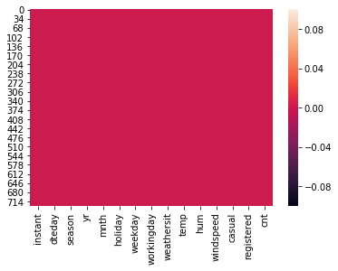

```python
sns.heatmap(bike.isnull())
```

```python
bike = bike.drop(labels = ['instant'], axis = 1)
```

```python
bike
```

|  | dteday | season | yr | mnth | holiday | weekday | workingday | weathersit | temp | hum | windspeed | casual | registered | cnt |
| --- | --- | --- | --- | --- | --- | --- | --- | --- | --- | --- | --- | --- | --- | --- |
| 0 | 1/1/2011 | 1 | 0 | 1 | 0 | 6 | 0 | 2 | 0.344167 | 0.805833 | 0.160446 | 331 | 654 | 985 |
| 1 | 1/2/2011 | 1 | 0 | 1 | 0 | 0 | 0 | 2 | 0.363478 | 0.696087 | 0.248539 | 131 | 670 | 801 |
| 2 | 1/3/2011 | 1 | 0 | 1 | 0 | 1 | 1 | 1 | 0.196364 | 0.437273 | 0.248309 | 120 | 1229 | 1349 |
| 3 | 1/4/2011 | 1 | 0 | 1 | 0 | 2 | 1 | 1 | 0.200000 | 0.590435 | 0.160296 | 108 | 1454 | 1562 |
| 4 | 1/5/2011 | 1 | 0 | 1 | 0 | 3 | 1 | 1 | 0.226957 | 0.436957 | 0.186900 | 82 | 1518 | 1600 |
| 5 | 1/6/2011 | 1 | 0 | 1 | 0 | 4 | 1 | 1 | 0.204348 | 0.518261 | 0.089565 | 88 | 1518 | 1606 |
| 6 | 1/7/2011 | 1 | 0 | 1 | 0 | 5 | 1 | 2 | 0.196522 | 0.498696 | 0.168726 | 148 | 1362 | 1510 |
| 7 | 1/8/2011 | 1 | 0 | 1 | 0 | 6 | 0 | 2 | 0.165000 | 0.535833 | 0.266804 | 68 | 891 | 959 |
| 8 | 1/9/2011 | 1 | 0 | 1 | 0 | 0 | 0 | 1 | 0.138333 | 0.434167 | 0.361950 | 54 | 768 | 822 |
| 9 | 1/10/2011 | 1 | 0 | 1 | 0 | 1 | 1 | 1 | 0.150833 | 0.482917 | 0.223267 | 41 | 1280 | 1321 |
| 10 | 1/11/2011 | 1 | 0 | 1 | 0 | 2 | 1 | 2 | 0.169091 | 0.686364 | 0.122132 | 43 | 1220 | 1263 |
| 11 | 1/12/2011 | 1 | 0 | 1 | 0 | 3 | 1 | 1 | 0.172727 | 0.599545 | 0.304627 | 25 | 1137 | 1162 |
| 12 | 1/13/2011 | 1 | 0 | 1 | 0 | 4 | 1 | 1 | 0.165000 | 0.470417 | 0.301000 | 38 | 1368 | 1406 |
| 13 | 1/14/2011 | 1 | 0 | 1 | 0 | 5 | 1 | 1 | 0.160870 | 0.537826 | 0.126548 | 54 | 1367 | 1421 |
| 14 | 1/15/2011 | 1 | 0 | 1 | 0 | 6 | 0 | 2 | 0.233333 | 0.498750 | 0.157963 | 222 | 1026 | 1248 |
| 15 | 1/16/2011 | 1 | 0 | 1 | 0 | 0 | 0 | 1 | 0.231667 | 0.483750 | 0.188433 | 251 | 953 | 1204 |
| 16 | 1/17/2011 | 1 | 0 | 1 | 1 | 1 | 0 | 2 | 0.175833 | 0.537500 | 0.194017 | 117 | 883 | 1000 |
| 17 | 1/18/2011 | 1 | 0 | 1 | 0 | 2 | 1 | 2 | 0.216667 | 0.861667 | 0.146775 | 9 | 674 | 683 |
| 18 | 1/19/2011 | 1 | 0 | 1 | 0 | 3 | 1 | 2 | 0.292174 | 0.741739 | 0.208317 | 78 | 1572 | 1650 |
| 19 | 1/20/2011 | 1 | 0 | 1 | 0 | 4 | 1 | 2 | 0.261667 | 0.538333 | 0.195904 | 83 | 1844 | 1927 |
| 20 | 1/21/2011 | 1 | 0 | 1 | 0 | 5 | 1 | 1 | 0.177500 | 0.457083 | 0.353242 | 75 | 1468 | 1543 |
| 21 | 1/22/2011 | 1 | 0 | 1 | 0 | 6 | 0 | 1 | 0.059130 | 0.400000 | 0.171970 | 93 | 888 | 981 |
| 22 | 1/23/2011 | 1 | 0 | 1 | 0 | 0 | 0 | 1 | 0.096522 | 0.436522 | 0.246600 | 150 | 836 | 986 |
| 23 | 1/24/2011 | 1 | 0 | 1 | 0 | 1 | 1 | 1 | 0.097391 | 0.491739 | 0.158330 | 86 | 1330 | 1416 |
| 24 | 1/25/2011 | 1 | 0 | 1 | 0 | 2 | 1 | 2 | 0.223478 | 0.616957 | 0.129796 | 186 | 1799 | 1985 |
| 25 | 1/26/2011 | 1 | 0 | 1 | 0 | 3 | 1 | 3 | 0.217500 | 0.862500 | 0.293850 | 34 | 472 | 506 |
| 26 | 1/27/2011 | 1 | 0 | 1 | 0 | 4 | 1 | 1 | 0.195000 | 0.687500 | 0.113837 | 15 | 416 | 431 |
| 27 | 1/28/2011 | 1 | 0 | 1 | 0 | 5 | 1 | 2 | 0.203478 | 0.793043 | 0.123300 | 38 | 1129 | 1167 |
| 28 | 1/29/2011 | 1 | 0 | 1 | 0 | 6 | 0 | 1 | 0.196522 | 0.651739 | 0.145365 | 123 | 975 | 1098 |
| 29 | 1/30/2011 | 1 | 0 | 1 | 0 | 0 | 0 | 1 | 0.216522 | 0.722174 | 0.073983 | 140 | 956 | 1096 |
| ... | ... | ... | ... | ... | ... | ... | ... | ... | ... | ... | ... | ... | ... | ... |
| 701 | 12/2/2012 | 4 | 1 | 12 | 0 | 0 | 0 | 2 | 0.347500 | 0.823333 | 0.124379 | 892 | 3757 | 4649 |
| 702 | 12/3/2012 | 4 | 1 | 12 | 0 | 1 | 1 | 1 | 0.452500 | 0.767500 | 0.082721 | 555 | 5679 | 6234 |
| 703 | 12/4/2012 | 4 | 1 | 12 | 0 | 2 | 1 | 1 | 0.475833 | 0.733750 | 0.174129 | 551 | 6055 | 6606 |
| 704 | 12/5/2012 | 4 | 1 | 12 | 0 | 3 | 1 | 1 | 0.438333 | 0.485000 | 0.324021 | 331 | 5398 | 5729 |
| 705 | 12/6/2012 | 4 | 1 | 12 | 0 | 4 | 1 | 1 | 0.255833 | 0.508750 | 0.174754 | 340 | 5035 | 5375 |
| 706 | 12/7/2012 | 4 | 1 | 12 | 0 | 5 | 1 | 2 | 0.320833 | 0.764167 | 0.130600 | 349 | 4659 | 5008 |
| 707 | 12/8/2012 | 4 | 1 | 12 | 0 | 6 | 0 | 2 | 0.381667 | 0.911250 | 0.101379 | 1153 | 4429 | 5582 |
| 708 | 12/9/2012 | 4 | 1 | 12 | 0 | 0 | 0 | 2 | 0.384167 | 0.905417 | 0.157975 | 441 | 2787 | 3228 |
| 709 | 12/10/2012 | 4 | 1 | 12 | 0 | 1 | 1 | 2 | 0.435833 | 0.925000 | 0.190308 | 329 | 4841 | 5170 |
| 710 | 12/11/2012 | 4 | 1 | 12 | 0 | 2 | 1 | 2 | 0.353333 | 0.596667 | 0.296037 | 282 | 5219 | 5501 |
| 711 | 12/12/2012 | 4 | 1 | 12 | 0 | 3 | 1 | 2 | 0.297500 | 0.538333 | 0.162937 | 310 | 5009 | 5319 |
| 712 | 12/13/2012 | 4 | 1 | 12 | 0 | 4 | 1 | 1 | 0.295833 | 0.485833 | 0.174129 | 425 | 5107 | 5532 |
| 713 | 12/14/2012 | 4 | 1 | 12 | 0 | 5 | 1 | 1 | 0.281667 | 0.642917 | 0.131229 | 429 | 5182 | 5611 |
| 714 | 12/15/2012 | 4 | 1 | 12 | 0 | 6 | 0 | 1 | 0.324167 | 0.650417 | 0.106350 | 767 | 4280 | 5047 |
| 715 | 12/16/2012 | 4 | 1 | 12 | 0 | 0 | 0 | 2 | 0.362500 | 0.838750 | 0.100742 | 538 | 3248 | 3786 |
| 716 | 12/17/2012 | 4 | 1 | 12 | 0 | 1 | 1 | 2 | 0.393333 | 0.907083 | 0.098258 | 212 | 4373 | 4585 |
| 717 | 12/18/2012 | 4 | 1 | 12 | 0 | 2 | 1 | 1 | 0.410833 | 0.666250 | 0.221404 | 433 | 5124 | 5557 |
| 718 | 12/19/2012 | 4 | 1 | 12 | 0 | 3 | 1 | 1 | 0.332500 | 0.625417 | 0.184092 | 333 | 4934 | 5267 |
| 719 | 12/20/2012 | 4 | 1 | 12 | 0 | 4 | 1 | 2 | 0.330000 | 0.667917 | 0.132463 | 314 | 3814 | 4128 |
| 720 | 12/21/2012 | 1 | 1 | 12 | 0 | 5 | 1 | 2 | 0.326667 | 0.556667 | 0.374383 | 221 | 3402 | 3623 |
| 721 | 12/22/2012 | 1 | 1 | 12 | 0 | 6 | 0 | 1 | 0.265833 | 0.441250 | 0.407346 | 205 | 1544 | 1749 |
| 722 | 12/23/2012 | 1 | 1 | 12 | 0 | 0 | 0 | 1 | 0.245833 | 0.515417 | 0.133083 | 408 | 1379 | 1787 |
| 723 | 12/24/2012 | 1 | 1 | 12 | 0 | 1 | 1 | 2 | 0.231304 | 0.791304 | 0.077230 | 174 | 746 | 920 |
| 724 | 12/25/2012 | 1 | 1 | 12 | 1 | 2 | 0 | 2 | 0.291304 | 0.734783 | 0.168726 | 440 | 573 | 1013 |
| 725 | 12/26/2012 | 1 | 1 | 12 | 0 | 3 | 1 | 3 | 0.243333 | 0.823333 | 0.316546 | 9 | 432 | 441 |
| 726 | 12/27/2012 | 1 | 1 | 12 | 0 | 4 | 1 | 2 | 0.254167 | 0.652917 | 0.350133 | 247 | 1867 | 2114 |
| 727 | 12/28/2012 | 1 | 1 | 12 | 0 | 5 | 1 | 2 | 0.253333 | 0.590000 | 0.155471 | 644 | 2451 | 3095 |
| 728 | 12/29/2012 | 1 | 1 | 12 | 0 | 6 | 0 | 2 | 0.253333 | 0.752917 | 0.124383 | 159 | 1182 | 1341 |
| 729 | 12/30/2012 | 1 | 1 | 12 | 0 | 0 | 0 | 1 | 0.255833 | 0.483333 | 0.350754 | 364 | 1432 | 1796 |
| 730 | 12/31/2012 | 1 | 1 | 12 | 0 | 1 | 1 | 2 | 0.215833 | 0.577500 | 0.154846 | 439 | 2290 | 2729 |

731 rows × 14 columns

```python
bike = bike.drop(labels = ['casual', 'registered'], axis = 1)
```

```python
bike
```

|  | dteday | season | yr | mnth | holiday | weekday | workingday | weathersit | temp | hum | windspeed | cnt |
| --- | --- | --- | --- | --- | --- | --- | --- | --- | --- | --- | --- | --- |
| 0 | 1/1/2011 | 1 | 0 | 1 | 0 | 6 | 0 | 2 | 0.344167 | 0.805833 | 0.160446 | 985 |
| 1 | 1/2/2011 | 1 | 0 | 1 | 0 | 0 | 0 | 2 | 0.363478 | 0.696087 | 0.248539 | 801 |
| 2 | 1/3/2011 | 1 | 0 | 1 | 0 | 1 | 1 | 1 | 0.196364 | 0.437273 | 0.248309 | 1349 |
| 3 | 1/4/2011 | 1 | 0 | 1 | 0 | 2 | 1 | 1 | 0.200000 | 0.590435 | 0.160296 | 1562 |
| 4 | 1/5/2011 | 1 | 0 | 1 | 0 | 3 | 1 | 1 | 0.226957 | 0.436957 | 0.186900 | 1600 |
| 5 | 1/6/2011 | 1 | 0 | 1 | 0 | 4 | 1 | 1 | 0.204348 | 0.518261 | 0.089565 | 1606 |
| 6 | 1/7/2011 | 1 | 0 | 1 | 0 | 5 | 1 | 2 | 0.196522 | 0.498696 | 0.168726 | 1510 |
| 7 | 1/8/2011 | 1 | 0 | 1 | 0 | 6 | 0 | 2 | 0.165000 | 0.535833 | 0.266804 | 959 |
| 8 | 1/9/2011 | 1 | 0 | 1 | 0 | 0 | 0 | 1 | 0.138333 | 0.434167 | 0.361950 | 822 |
| 9 | 1/10/2011 | 1 | 0 | 1 | 0 | 1 | 1 | 1 | 0.150833 | 0.482917 | 0.223267 | 1321 |
| 10 | 1/11/2011 | 1 | 0 | 1 | 0 | 2 | 1 | 2 | 0.169091 | 0.686364 | 0.122132 | 1263 |
| 11 | 1/12/2011 | 1 | 0 | 1 | 0 | 3 | 1 | 1 | 0.172727 | 0.599545 | 0.304627 | 1162 |
| 12 | 1/13/2011 | 1 | 0 | 1 | 0 | 4 | 1 | 1 | 0.165000 | 0.470417 | 0.301000 | 1406 |
| 13 | 1/14/2011 | 1 | 0 | 1 | 0 | 5 | 1 | 1 | 0.160870 | 0.537826 | 0.126548 | 1421 |
| 14 | 1/15/2011 | 1 | 0 | 1 | 0 | 6 | 0 | 2 | 0.233333 | 0.498750 | 0.157963 | 1248 |
| 15 | 1/16/2011 | 1 | 0 | 1 | 0 | 0 | 0 | 1 | 0.231667 | 0.483750 | 0.188433 | 1204 |
| 16 | 1/17/2011 | 1 | 0 | 1 | 1 | 1 | 0 | 2 | 0.175833 | 0.537500 | 0.194017 | 1000 |
| 17 | 1/18/2011 | 1 | 0 | 1 | 0 | 2 | 1 | 2 | 0.216667 | 0.861667 | 0.146775 | 683 |
| 18 | 1/19/2011 | 1 | 0 | 1 | 0 | 3 | 1 | 2 | 0.292174 | 0.741739 | 0.208317 | 1650 |
| 19 | 1/20/2011 | 1 | 0 | 1 | 0 | 4 | 1 | 2 | 0.261667 | 0.538333 | 0.195904 | 1927 |
| 20 | 1/21/2011 | 1 | 0 | 1 | 0 | 5 | 1 | 1 | 0.177500 | 0.457083 | 0.353242 | 1543 |
| 21 | 1/22/2011 | 1 | 0 | 1 | 0 | 6 | 0 | 1 | 0.059130 | 0.400000 | 0.171970 | 981 |
| 22 | 1/23/2011 | 1 | 0 | 1 | 0 | 0 | 0 | 1 | 0.096522 | 0.436522 | 0.246600 | 986 |
| 23 | 1/24/2011 | 1 | 0 | 1 | 0 | 1 | 1 | 1 | 0.097391 | 0.491739 | 0.158330 | 1416 |
| 24 | 1/25/2011 | 1 | 0 | 1 | 0 | 2 | 1 | 2 | 0.223478 | 0.616957 | 0.129796 | 1985 |
| 25 | 1/26/2011 | 1 | 0 | 1 | 0 | 3 | 1 | 3 | 0.217500 | 0.862500 | 0.293850 | 506 |
| 26 | 1/27/2011 | 1 | 0 | 1 | 0 | 4 | 1 | 1 | 0.195000 | 0.687500 | 0.113837 | 431 |
| 27 | 1/28/2011 | 1 | 0 | 1 | 0 | 5 | 1 | 2 | 0.203478 | 0.793043 | 0.123300 | 1167 |
| 28 | 1/29/2011 | 1 | 0 | 1 | 0 | 6 | 0 | 1 | 0.196522 | 0.651739 | 0.145365 | 1098 |
| 29 | 1/30/2011 | 1 | 0 | 1 | 0 | 0 | 0 | 1 | 0.216522 | 0.722174 | 0.073983 | 1096 |
| ... | ... | ... | ... | ... | ... | ... | ... | ... | ... | ... | ... | ... |
| 701 | 12/2/2012 | 4 | 1 | 12 | 0 | 0 | 0 | 2 | 0.347500 | 0.823333 | 0.124379 | 4649 |
| 702 | 12/3/2012 | 4 | 1 | 12 | 0 | 1 | 1 | 1 | 0.452500 | 0.767500 | 0.082721 | 6234 |
| 703 | 12/4/2012 | 4 | 1 | 12 | 0 | 2 | 1 | 1 | 0.475833 | 0.733750 | 0.174129 | 6606 |
| 704 | 12/5/2012 | 4 | 1 | 12 | 0 | 3 | 1 | 1 | 0.438333 | 0.485000 | 0.324021 | 5729 |
| 705 | 12/6/2012 | 4 | 1 | 12 | 0 | 4 | 1 | 1 | 0.255833 | 0.508750 | 0.174754 | 5375 |
| 706 | 12/7/2012 | 4 | 1 | 12 | 0 | 5 | 1 | 2 | 0.320833 | 0.764167 | 0.130600 | 5008 |
| 707 | 12/8/2012 | 4 | 1 | 12 | 0 | 6 | 0 | 2 | 0.381667 | 0.911250 | 0.101379 | 5582 |
| 708 | 12/9/2012 | 4 | 1 | 12 | 0 | 0 | 0 | 2 | 0.384167 | 0.905417 | 0.157975 | 3228 |
| 709 | 12/10/2012 | 4 | 1 | 12 | 0 | 1 | 1 | 2 | 0.435833 | 0.925000 | 0.190308 | 5170 |
| 710 | 12/11/2012 | 4 | 1 | 12 | 0 | 2 | 1 | 2 | 0.353333 | 0.596667 | 0.296037 | 5501 |
| 711 | 12/12/2012 | 4 | 1 | 12 | 0 | 3 | 1 | 2 | 0.297500 | 0.538333 | 0.162937 | 5319 |
| 712 | 12/13/2012 | 4 | 1 | 12 | 0 | 4 | 1 | 1 | 0.295833 | 0.485833 | 0.174129 | 5532 |
| 713 | 12/14/2012 | 4 | 1 | 12 | 0 | 5 | 1 | 1 | 0.281667 | 0.642917 | 0.131229 | 5611 |
| 714 | 12/15/2012 | 4 | 1 | 12 | 0 | 6 | 0 | 1 | 0.324167 | 0.650417 | 0.106350 | 5047 |
| 715 | 12/16/2012 | 4 | 1 | 12 | 0 | 0 | 0 | 2 | 0.362500 | 0.838750 | 0.100742 | 3786 |
| 716 | 12/17/2012 | 4 | 1 | 12 | 0 | 1 | 1 | 2 | 0.393333 | 0.907083 | 0.098258 | 4585 |
| 717 | 12/18/2012 | 4 | 1 | 12 | 0 | 2 | 1 | 1 | 0.410833 | 0.666250 | 0.221404 | 5557 |
| 718 | 12/19/2012 | 4 | 1 | 12 | 0 | 3 | 1 | 1 | 0.332500 | 0.625417 | 0.184092 | 5267 |
| 719 | 12/20/2012 | 4 | 1 | 12 | 0 | 4 | 1 | 2 | 0.330000 | 0.667917 | 0.132463 | 4128 |
| 720 | 12/21/2012 | 1 | 1 | 12 | 0 | 5 | 1 | 2 | 0.326667 | 0.556667 | 0.374383 | 3623 |
| 721 | 12/22/2012 | 1 | 1 | 12 | 0 | 6 | 0 | 1 | 0.265833 | 0.441250 | 0.407346 | 1749 |
| 722 | 12/23/2012 | 1 | 1 | 12 | 0 | 0 | 0 | 1 | 0.245833 | 0.515417 | 0.133083 | 1787 |
| 723 | 12/24/2012 | 1 | 1 | 12 | 0 | 1 | 1 | 2 | 0.231304 | 0.791304 | 0.077230 | 920 |
| 724 | 12/25/2012 | 1 | 1 | 12 | 1 | 2 | 0 | 2 | 0.291304 | 0.734783 | 0.168726 | 1013 |
| 725 | 12/26/2012 | 1 | 1 | 12 | 0 | 3 | 1 | 3 | 0.243333 | 0.823333 | 0.316546 | 441 |
| 726 | 12/27/2012 | 1 | 1 | 12 | 0 | 4 | 1 | 2 | 0.254167 | 0.652917 | 0.350133 | 2114 |
| 727 | 12/28/2012 | 1 | 1 | 12 | 0 | 5 | 1 | 2 | 0.253333 | 0.590000 | 0.155471 | 3095 |
| 728 | 12/29/2012 | 1 | 1 | 12 | 0 | 6 | 0 | 2 | 0.253333 | 0.752917 | 0.124383 | 1341 |
| 729 | 12/30/2012 | 1 | 1 | 12 | 0 | 0 | 0 | 1 | 0.255833 | 0.483333 | 0.350754 | 1796 |
| 730 | 12/31/2012 | 1 | 1 | 12 | 0 | 1 | 1 | 2 | 0.215833 | 0.577500 | 0.154846 | 2729 |

731 rows × 12 columns

```python
bike.dteday = pd.to_datetime(bike.dteday, format = '%m/%d/%Y')
```

```python
bike
```

|  | dteday | season | yr | mnth | holiday | weekday | workingday | weathersit | temp | hum | windspeed | cnt |
| --- | --- | --- | --- | --- | --- | --- | --- | --- | --- | --- | --- | --- |
| 0 | 2011-01-01 | 1 | 0 | 1 | 0 | 6 | 0 | 2 | 0.344167 | 0.805833 | 0.160446 | 985 |
| 1 | 2011-01-02 | 1 | 0 | 1 | 0 | 0 | 0 | 2 | 0.363478 | 0.696087 | 0.248539 | 801 |
| 2 | 2011-01-03 | 1 | 0 | 1 | 0 | 1 | 1 | 1 | 0.196364 | 0.437273 | 0.248309 | 1349 |
| 3 | 2011-01-04 | 1 | 0 | 1 | 0 | 2 | 1 | 1 | 0.200000 | 0.590435 | 0.160296 | 1562 |
| 4 | 2011-01-05 | 1 | 0 | 1 | 0 | 3 | 1 | 1 | 0.226957 | 0.436957 | 0.186900 | 1600 |
| 5 | 2011-01-06 | 1 | 0 | 1 | 0 | 4 | 1 | 1 | 0.204348 | 0.518261 | 0.089565 | 1606 |
| 6 | 2011-01-07 | 1 | 0 | 1 | 0 | 5 | 1 | 2 | 0.196522 | 0.498696 | 0.168726 | 1510 |
| 7 | 2011-01-08 | 1 | 0 | 1 | 0 | 6 | 0 | 2 | 0.165000 | 0.535833 | 0.266804 | 959 |
| 8 | 2011-01-09 | 1 | 0 | 1 | 0 | 0 | 0 | 1 | 0.138333 | 0.434167 | 0.361950 | 822 |
| 9 | 2011-01-10 | 1 | 0 | 1 | 0 | 1 | 1 | 1 | 0.150833 | 0.482917 | 0.223267 | 1321 |
| 10 | 2011-01-11 | 1 | 0 | 1 | 0 | 2 | 1 | 2 | 0.169091 | 0.686364 | 0.122132 | 1263 |
| 11 | 2011-01-12 | 1 | 0 | 1 | 0 | 3 | 1 | 1 | 0.172727 | 0.599545 | 0.304627 | 1162 |
| 12 | 2011-01-13 | 1 | 0 | 1 | 0 | 4 | 1 | 1 | 0.165000 | 0.470417 | 0.301000 | 1406 |
| 13 | 2011-01-14 | 1 | 0 | 1 | 0 | 5 | 1 | 1 | 0.160870 | 0.537826 | 0.126548 | 1421 |
| 14 | 2011-01-15 | 1 | 0 | 1 | 0 | 6 | 0 | 2 | 0.233333 | 0.498750 | 0.157963 | 1248 |
| 15 | 2011-01-16 | 1 | 0 | 1 | 0 | 0 | 0 | 1 | 0.231667 | 0.483750 | 0.188433 | 1204 |
| 16 | 2011-01-17 | 1 | 0 | 1 | 1 | 1 | 0 | 2 | 0.175833 | 0.537500 | 0.194017 | 1000 |
| 17 | 2011-01-18 | 1 | 0 | 1 | 0 | 2 | 1 | 2 | 0.216667 | 0.861667 | 0.146775 | 683 |
| 18 | 2011-01-19 | 1 | 0 | 1 | 0 | 3 | 1 | 2 | 0.292174 | 0.741739 | 0.208317 | 1650 |
| 19 | 2011-01-20 | 1 | 0 | 1 | 0 | 4 | 1 | 2 | 0.261667 | 0.538333 | 0.195904 | 1927 |
| 20 | 2011-01-21 | 1 | 0 | 1 | 0 | 5 | 1 | 1 | 0.177500 | 0.457083 | 0.353242 | 1543 |
| 21 | 2011-01-22 | 1 | 0 | 1 | 0 | 6 | 0 | 1 | 0.059130 | 0.400000 | 0.171970 | 981 |
| 22 | 2011-01-23 | 1 | 0 | 1 | 0 | 0 | 0 | 1 | 0.096522 | 0.436522 | 0.246600 | 986 |
| 23 | 2011-01-24 | 1 | 0 | 1 | 0 | 1 | 1 | 1 | 0.097391 | 0.491739 | 0.158330 | 1416 |
| 24 | 2011-01-25 | 1 | 0 | 1 | 0 | 2 | 1 | 2 | 0.223478 | 0.616957 | 0.129796 | 1985 |
| 25 | 2011-01-26 | 1 | 0 | 1 | 0 | 3 | 1 | 3 | 0.217500 | 0.862500 | 0.293850 | 506 |
| 26 | 2011-01-27 | 1 | 0 | 1 | 0 | 4 | 1 | 1 | 0.195000 | 0.687500 | 0.113837 | 431 |
| 27 | 2011-01-28 | 1 | 0 | 1 | 0 | 5 | 1 | 2 | 0.203478 | 0.793043 | 0.123300 | 1167 |
| 28 | 2011-01-29 | 1 | 0 | 1 | 0 | 6 | 0 | 1 | 0.196522 | 0.651739 | 0.145365 | 1098 |
| 29 | 2011-01-30 | 1 | 0 | 1 | 0 | 0 | 0 | 1 | 0.216522 | 0.722174 | 0.073983 | 1096 |
| ... | ... | ... | ... | ... | ... | ... | ... | ... | ... | ... | ... | ... |
| 701 | 2012-12-02 | 4 | 1 | 12 | 0 | 0 | 0 | 2 | 0.347500 | 0.823333 | 0.124379 | 4649 |
| 702 | 2012-12-03 | 4 | 1 | 12 | 0 | 1 | 1 | 1 | 0.452500 | 0.767500 | 0.082721 | 6234 |
| 703 | 2012-12-04 | 4 | 1 | 12 | 0 | 2 | 1 | 1 | 0.475833 | 0.733750 | 0.174129 | 6606 |
| 704 | 2012-12-05 | 4 | 1 | 12 | 0 | 3 | 1 | 1 | 0.438333 | 0.485000 | 0.324021 | 5729 |
| 705 | 2012-12-06 | 4 | 1 | 12 | 0 | 4 | 1 | 1 | 0.255833 | 0.508750 | 0.174754 | 5375 |
| 706 | 2012-12-07 | 4 | 1 | 12 | 0 | 5 | 1 | 2 | 0.320833 | 0.764167 | 0.130600 | 5008 |
| 707 | 2012-12-08 | 4 | 1 | 12 | 0 | 6 | 0 | 2 | 0.381667 | 0.911250 | 0.101379 | 5582 |
| 708 | 2012-12-09 | 4 | 1 | 12 | 0 | 0 | 0 | 2 | 0.384167 | 0.905417 | 0.157975 | 3228 |
| 709 | 2012-12-10 | 4 | 1 | 12 | 0 | 1 | 1 | 2 | 0.435833 | 0.925000 | 0.190308 | 5170 |
| 710 | 2012-12-11 | 4 | 1 | 12 | 0 | 2 | 1 | 2 | 0.353333 | 0.596667 | 0.296037 | 5501 |
| 711 | 2012-12-12 | 4 | 1 | 12 | 0 | 3 | 1 | 2 | 0.297500 | 0.538333 | 0.162937 | 5319 |
| 712 | 2012-12-13 | 4 | 1 | 12 | 0 | 4 | 1 | 1 | 0.295833 | 0.485833 | 0.174129 | 5532 |
| 713 | 2012-12-14 | 4 | 1 | 12 | 0 | 5 | 1 | 1 | 0.281667 | 0.642917 | 0.131229 | 5611 |
| 714 | 2012-12-15 | 4 | 1 | 12 | 0 | 6 | 0 | 1 | 0.324167 | 0.650417 | 0.106350 | 5047 |
| 715 | 2012-12-16 | 4 | 1 | 12 | 0 | 0 | 0 | 2 | 0.362500 | 0.838750 | 0.100742 | 3786 |
| 716 | 2012-12-17 | 4 | 1 | 12 | 0 | 1 | 1 | 2 | 0.393333 | 0.907083 | 0.098258 | 4585 |
| 717 | 2012-12-18 | 4 | 1 | 12 | 0 | 2 | 1 | 1 | 0.410833 | 0.666250 | 0.221404 | 5557 |
| 718 | 2012-12-19 | 4 | 1 | 12 | 0 | 3 | 1 | 1 | 0.332500 | 0.625417 | 0.184092 | 5267 |
| 719 | 2012-12-20 | 4 | 1 | 12 | 0 | 4 | 1 | 2 | 0.330000 | 0.667917 | 0.132463 | 4128 |
| 720 | 2012-12-21 | 1 | 1 | 12 | 0 | 5 | 1 | 2 | 0.326667 | 0.556667 | 0.374383 | 3623 |
| 721 | 2012-12-22 | 1 | 1 | 12 | 0 | 6 | 0 | 1 | 0.265833 | 0.441250 | 0.407346 | 1749 |
| 722 | 2012-12-23 | 1 | 1 | 12 | 0 | 0 | 0 | 1 | 0.245833 | 0.515417 | 0.133083 | 1787 |
| 723 | 2012-12-24 | 1 | 1 | 12 | 0 | 1 | 1 | 2 | 0.231304 | 0.791304 | 0.077230 | 920 |
| 724 | 2012-12-25 | 1 | 1 | 12 | 1 | 2 | 0 | 2 | 0.291304 | 0.734783 | 0.168726 | 1013 |
| 725 | 2012-12-26 | 1 | 1 | 12 | 0 | 3 | 1 | 3 | 0.243333 | 0.823333 | 0.316546 | 441 |
| 726 | 2012-12-27 | 1 | 1 | 12 | 0 | 4 | 1 | 2 | 0.254167 | 0.652917 | 0.350133 | 2114 |
| 727 | 2012-12-28 | 1 | 1 | 12 | 0 | 5 | 1 | 2 | 0.253333 | 0.590000 | 0.155471 | 3095 |
| 728 | 2012-12-29 | 1 | 1 | 12 | 0 | 6 | 0 | 2 | 0.253333 | 0.752917 | 0.124383 | 1341 |
| 729 | 2012-12-30 | 1 | 1 | 12 | 0 | 0 | 0 | 1 | 0.255833 | 0.483333 | 0.350754 | 1796 |
| 730 | 2012-12-31 | 1 | 1 | 12 | 0 | 1 | 1 | 2 | 0.215833 | 0.577500 | 0.154846 | 2729 |

731 rows × 12 columns

```python
bike.index = pd.DatetimeIndex(bike.dteday)
```

```python
bike
```

| dteday | dteday | season | yr | mnth | holiday | weekday | workingday | weathersit | temp | hum | windspeed | cnt |
| --- | --- | --- | --- | --- | --- | --- | --- | --- | --- | --- | --- | --- |
| 2011-01-01 | 2011-01-01 | 1 | 0 | 1 | 0 | 6 | 0 | 2 | 0.344167 | 0.805833 | 0.160446 | 985 |
| 2011-01-02 | 2011-01-02 | 1 | 0 | 1 | 0 | 0 | 0 | 2 | 0.363478 | 0.696087 | 0.248539 | 801 |
| 2011-01-03 | 2011-01-03 | 1 | 0 | 1 | 0 | 1 | 1 | 1 | 0.196364 | 0.437273 | 0.248309 | 1349 |
| 2011-01-04 | 2011-01-04 | 1 | 0 | 1 | 0 | 2 | 1 | 1 | 0.200000 | 0.590435 | 0.160296 | 1562 |
| 2011-01-05 | 2011-01-05 | 1 | 0 | 1 | 0 | 3 | 1 | 1 | 0.226957 | 0.436957 | 0.186900 | 1600 |
| 2011-01-06 | 2011-01-06 | 1 | 0 | 1 | 0 | 4 | 1 | 1 | 0.204348 | 0.518261 | 0.089565 | 1606 |
| 2011-01-07 | 2011-01-07 | 1 | 0 | 1 | 0 | 5 | 1 | 2 | 0.196522 | 0.498696 | 0.168726 | 1510 |
| 2011-01-08 | 2011-01-08 | 1 | 0 | 1 | 0 | 6 | 0 | 2 | 0.165000 | 0.535833 | 0.266804 | 959 |
| 2011-01-09 | 2011-01-09 | 1 | 0 | 1 | 0 | 0 | 0 | 1 | 0.138333 | 0.434167 | 0.361950 | 822 |
| 2011-01-10 | 2011-01-10 | 1 | 0 | 1 | 0 | 1 | 1 | 1 | 0.150833 | 0.482917 | 0.223267 | 1321 |
| 2011-01-11 | 2011-01-11 | 1 | 0 | 1 | 0 | 2 | 1 | 2 | 0.169091 | 0.686364 | 0.122132 | 1263 |
| 2011-01-12 | 2011-01-12 | 1 | 0 | 1 | 0 | 3 | 1 | 1 | 0.172727 | 0.599545 | 0.304627 | 1162 |
| 2011-01-13 | 2011-01-13 | 1 | 0 | 1 | 0 | 4 | 1 | 1 | 0.165000 | 0.470417 | 0.301000 | 1406 |
| 2011-01-14 | 2011-01-14 | 1 | 0 | 1 | 0 | 5 | 1 | 1 | 0.160870 | 0.537826 | 0.126548 | 1421 |
| 2011-01-15 | 2011-01-15 | 1 | 0 | 1 | 0 | 6 | 0 | 2 | 0.233333 | 0.498750 | 0.157963 | 1248 |
| 2011-01-16 | 2011-01-16 | 1 | 0 | 1 | 0 | 0 | 0 | 1 | 0.231667 | 0.483750 | 0.188433 | 1204 |
| 2011-01-17 | 2011-01-17 | 1 | 0 | 1 | 1 | 1 | 0 | 2 | 0.175833 | 0.537500 | 0.194017 | 1000 |
| 2011-01-18 | 2011-01-18 | 1 | 0 | 1 | 0 | 2 | 1 | 2 | 0.216667 | 0.861667 | 0.146775 | 683 |
| 2011-01-19 | 2011-01-19 | 1 | 0 | 1 | 0 | 3 | 1 | 2 | 0.292174 | 0.741739 | 0.208317 | 1650 |
| 2011-01-20 | 2011-01-20 | 1 | 0 | 1 | 0 | 4 | 1 | 2 | 0.261667 | 0.538333 | 0.195904 | 1927 |
| 2011-01-21 | 2011-01-21 | 1 | 0 | 1 | 0 | 5 | 1 | 1 | 0.177500 | 0.457083 | 0.353242 | 1543 |
| 2011-01-22 | 2011-01-22 | 1 | 0 | 1 | 0 | 6 | 0 | 1 | 0.059130 | 0.400000 | 0.171970 | 981 |
| 2011-01-23 | 2011-01-23 | 1 | 0 | 1 | 0 | 0 | 0 | 1 | 0.096522 | 0.436522 | 0.246600 | 986 |
| 2011-01-24 | 2011-01-24 | 1 | 0 | 1 | 0 | 1 | 1 | 1 | 0.097391 | 0.491739 | 0.158330 | 1416 |
| 2011-01-25 | 2011-01-25 | 1 | 0 | 1 | 0 | 2 | 1 | 2 | 0.223478 | 0.616957 | 0.129796 | 1985 |
| 2011-01-26 | 2011-01-26 | 1 | 0 | 1 | 0 | 3 | 1 | 3 | 0.217500 | 0.862500 | 0.293850 | 506 |
| 2011-01-27 | 2011-01-27 | 1 | 0 | 1 | 0 | 4 | 1 | 1 | 0.195000 | 0.687500 | 0.113837 | 431 |
| 2011-01-28 | 2011-01-28 | 1 | 0 | 1 | 0 | 5 | 1 | 2 | 0.203478 | 0.793043 | 0.123300 | 1167 |
| 2011-01-29 | 2011-01-29 | 1 | 0 | 1 | 0 | 6 | 0 | 1 | 0.196522 | 0.651739 | 0.145365 | 1098 |
| 2011-01-30 | 2011-01-30 | 1 | 0 | 1 | 0 | 0 | 0 | 1 | 0.216522 | 0.722174 | 0.073983 | 1096 |
| ... | ... | ... | ... | ... | ... | ... | ... | ... | ... | ... | ... | ... |
| 2012-12-02 | 2012-12-02 | 4 | 1 | 12 | 0 | 0 | 0 | 2 | 0.347500 | 0.823333 | 0.124379 | 4649 |
| 2012-12-03 | 2012-12-03 | 4 | 1 | 12 | 0 | 1 | 1 | 1 | 0.452500 | 0.767500 | 0.082721 | 6234 |
| 2012-12-04 | 2012-12-04 | 4 | 1 | 12 | 0 | 2 | 1 | 1 | 0.475833 | 0.733750 | 0.174129 | 6606 |
| 2012-12-05 | 2012-12-05 | 4 | 1 | 12 | 0 | 3 | 1 | 1 | 0.438333 | 0.485000 | 0.324021 | 5729 |
| 2012-12-06 | 2012-12-06 | 4 | 1 | 12 | 0 | 4 | 1 | 1 | 0.255833 | 0.508750 | 0.174754 | 5375 |
| 2012-12-07 | 2012-12-07 | 4 | 1 | 12 | 0 | 5 | 1 | 2 | 0.320833 | 0.764167 | 0.130600 | 5008 |
| 2012-12-08 | 2012-12-08 | 4 | 1 | 12 | 0 | 6 | 0 | 2 | 0.381667 | 0.911250 | 0.101379 | 5582 |
| 2012-12-09 | 2012-12-09 | 4 | 1 | 12 | 0 | 0 | 0 | 2 | 0.384167 | 0.905417 | 0.157975 | 3228 |
| 2012-12-10 | 2012-12-10 | 4 | 1 | 12 | 0 | 1 | 1 | 2 | 0.435833 | 0.925000 | 0.190308 | 5170 |
| 2012-12-11 | 2012-12-11 | 4 | 1 | 12 | 0 | 2 | 1 | 2 | 0.353333 | 0.596667 | 0.296037 | 5501 |
| 2012-12-12 | 2012-12-12 | 4 | 1 | 12 | 0 | 3 | 1 | 2 | 0.297500 | 0.538333 | 0.162937 | 5319 |
| 2012-12-13 | 2012-12-13 | 4 | 1 | 12 | 0 | 4 | 1 | 1 | 0.295833 | 0.485833 | 0.174129 | 5532 |
| 2012-12-14 | 2012-12-14 | 4 | 1 | 12 | 0 | 5 | 1 | 1 | 0.281667 | 0.642917 | 0.131229 | 5611 |
| 2012-12-15 | 2012-12-15 | 4 | 1 | 12 | 0 | 6 | 0 | 1 | 0.324167 | 0.650417 | 0.106350 | 5047 |
| 2012-12-16 | 2012-12-16 | 4 | 1 | 12 | 0 | 0 | 0 | 2 | 0.362500 | 0.838750 | 0.100742 | 3786 |
| 2012-12-17 | 2012-12-17 | 4 | 1 | 12 | 0 | 1 | 1 | 2 | 0.393333 | 0.907083 | 0.098258 | 4585 |
| 2012-12-18 | 2012-12-18 | 4 | 1 | 12 | 0 | 2 | 1 | 1 | 0.410833 | 0.666250 | 0.221404 | 5557 |
| 2012-12-19 | 2012-12-19 | 4 | 1 | 12 | 0 | 3 | 1 | 1 | 0.332500 | 0.625417 | 0.184092 | 5267 |
| 2012-12-20 | 2012-12-20 | 4 | 1 | 12 | 0 | 4 | 1 | 2 | 0.330000 | 0.667917 | 0.132463 | 4128 |
| 2012-12-21 | 2012-12-21 | 1 | 1 | 12 | 0 | 5 | 1 | 2 | 0.326667 | 0.556667 | 0.374383 | 3623 |
| 2012-12-22 | 2012-12-22 | 1 | 1 | 12 | 0 | 6 | 0 | 1 | 0.265833 | 0.441250 | 0.407346 | 1749 |
| 2012-12-23 | 2012-12-23 | 1 | 1 | 12 | 0 | 0 | 0 | 1 | 0.245833 | 0.515417 | 0.133083 | 1787 |
| 2012-12-24 | 2012-12-24 | 1 | 1 | 12 | 0 | 1 | 1 | 2 | 0.231304 | 0.791304 | 0.077230 | 920 |
| 2012-12-25 | 2012-12-25 | 1 | 1 | 12 | 1 | 2 | 0 | 2 | 0.291304 | 0.734783 | 0.168726 | 1013 |
| 2012-12-26 | 2012-12-26 | 1 | 1 | 12 | 0 | 3 | 1 | 3 | 0.243333 | 0.823333 | 0.316546 | 441 |
| 2012-12-27 | 2012-12-27 | 1 | 1 | 12 | 0 | 4 | 1 | 2 | 0.254167 | 0.652917 | 0.350133 | 2114 |
| 2012-12-28 | 2012-12-28 | 1 | 1 | 12 | 0 | 5 | 1 | 2 | 0.253333 | 0.590000 | 0.155471 | 3095 |
| 2012-12-29 | 2012-12-29 | 1 | 1 | 12 | 0 | 6 | 0 | 2 | 0.253333 | 0.752917 | 0.124383 | 1341 |
| 2012-12-30 | 2012-12-30 | 1 | 1 | 12 | 0 | 0 | 0 | 1 | 0.255833 | 0.483333 | 0.350754 | 1796 |
| 2012-12-31 | 2012-12-31 | 1 | 1 | 12 | 0 | 1 | 1 | 2 | 0.215833 | 0.577500 | 0.154846 | 2729 |

731 rows × 12 columns

```python
bike = bike.drop(labels = ['dteday'], axis = 1)
```

```python
bike
```

| dteday | season | yr | mnth | holiday | weekday | workingday | weathersit | temp | hum | windspeed | cnt |
| --- | --- | --- | --- | --- | --- | --- | --- | --- | --- | --- | --- |
| 2011-01-01 | 1 | 0 | 1 | 0 | 6 | 0 | 2 | 0.344167 | 0.805833 | 0.160446 | 985 |
| 2011-01-02 | 1 | 0 | 1 | 0 | 0 | 0 | 2 | 0.363478 | 0.696087 | 0.248539 | 801 |
| 2011-01-03 | 1 | 0 | 1 | 0 | 1 | 1 | 1 | 0.196364 | 0.437273 | 0.248309 | 1349 |
| 2011-01-04 | 1 | 0 | 1 | 0 | 2 | 1 | 1 | 0.200000 | 0.590435 | 0.160296 | 1562 |
| 2011-01-05 | 1 | 0 | 1 | 0 | 3 | 1 | 1 | 0.226957 | 0.436957 | 0.186900 | 1600 |
| 2011-01-06 | 1 | 0 | 1 | 0 | 4 | 1 | 1 | 0.204348 | 0.518261 | 0.089565 | 1606 |
| 2011-01-07 | 1 | 0 | 1 | 0 | 5 | 1 | 2 | 0.196522 | 0.498696 | 0.168726 | 1510 |
| 2011-01-08 | 1 | 0 | 1 | 0 | 6 | 0 | 2 | 0.165000 | 0.535833 | 0.266804 | 959 |
| 2011-01-09 | 1 | 0 | 1 | 0 | 0 | 0 | 1 | 0.138333 | 0.434167 | 0.361950 | 822 |
| 2011-01-10 | 1 | 0 | 1 | 0 | 1 | 1 | 1 | 0.150833 | 0.482917 | 0.223267 | 1321 |
| 2011-01-11 | 1 | 0 | 1 | 0 | 2 | 1 | 2 | 0.169091 | 0.686364 | 0.122132 | 1263 |
| 2011-01-12 | 1 | 0 | 1 | 0 | 3 | 1 | 1 | 0.172727 | 0.599545 | 0.304627 | 1162 |
| 2011-01-13 | 1 | 0 | 1 | 0 | 4 | 1 | 1 | 0.165000 | 0.470417 | 0.301000 | 1406 |
| 2011-01-14 | 1 | 0 | 1 | 0 | 5 | 1 | 1 | 0.160870 | 0.537826 | 0.126548 | 1421 |
| 2011-01-15 | 1 | 0 | 1 | 0 | 6 | 0 | 2 | 0.233333 | 0.498750 | 0.157963 | 1248 |
| 2011-01-16 | 1 | 0 | 1 | 0 | 0 | 0 | 1 | 0.231667 | 0.483750 | 0.188433 | 1204 |
| 2011-01-17 | 1 | 0 | 1 | 1 | 1 | 0 | 2 | 0.175833 | 0.537500 | 0.194017 | 1000 |
| 2011-01-18 | 1 | 0 | 1 | 0 | 2 | 1 | 2 | 0.216667 | 0.861667 | 0.146775 | 683 |
| 2011-01-19 | 1 | 0 | 1 | 0 | 3 | 1 | 2 | 0.292174 | 0.741739 | 0.208317 | 1650 |
| 2011-01-20 | 1 | 0 | 1 | 0 | 4 | 1 | 2 | 0.261667 | 0.538333 | 0.195904 | 1927 |
| 2011-01-21 | 1 | 0 | 1 | 0 | 5 | 1 | 1 | 0.177500 | 0.457083 | 0.353242 | 1543 |
| 2011-01-22 | 1 | 0 | 1 | 0 | 6 | 0 | 1 | 0.059130 | 0.400000 | 0.171970 | 981 |
| 2011-01-23 | 1 | 0 | 1 | 0 | 0 | 0 | 1 | 0.096522 | 0.436522 | 0.246600 | 986 |
| 2011-01-24 | 1 | 0 | 1 | 0 | 1 | 1 | 1 | 0.097391 | 0.491739 | 0.158330 | 1416 |
| 2011-01-25 | 1 | 0 | 1 | 0 | 2 | 1 | 2 | 0.223478 | 0.616957 | 0.129796 | 1985 |
| 2011-01-26 | 1 | 0 | 1 | 0 | 3 | 1 | 3 | 0.217500 | 0.862500 | 0.293850 | 506 |
| 2011-01-27 | 1 | 0 | 1 | 0 | 4 | 1 | 1 | 0.195000 | 0.687500 | 0.113837 | 431 |
| 2011-01-28 | 1 | 0 | 1 | 0 | 5 | 1 | 2 | 0.203478 | 0.793043 | 0.123300 | 1167 |
| 2011-01-29 | 1 | 0 | 1 | 0 | 6 | 0 | 1 | 0.196522 | 0.651739 | 0.145365 | 1098 |
| 2011-01-30 | 1 | 0 | 1 | 0 | 0 | 0 | 1 | 0.216522 | 0.722174 | 0.073983 | 1096 |
| ... | ... | ... | ... | ... | ... | ... | ... | ... | ... | ... | ... |
| 2012-12-02 | 4 | 1 | 12 | 0 | 0 | 0 | 2 | 0.347500 | 0.823333 | 0.124379 | 4649 |
| 2012-12-03 | 4 | 1 | 12 | 0 | 1 | 1 | 1 | 0.452500 | 0.767500 | 0.082721 | 6234 |
| 2012-12-04 | 4 | 1 | 12 | 0 | 2 | 1 | 1 | 0.475833 | 0.733750 | 0.174129 | 6606 |
| 2012-12-05 | 4 | 1 | 12 | 0 | 3 | 1 | 1 | 0.438333 | 0.485000 | 0.324021 | 5729 |
| 2012-12-06 | 4 | 1 | 12 | 0 | 4 | 1 | 1 | 0.255833 | 0.508750 | 0.174754 | 5375 |
| 2012-12-07 | 4 | 1 | 12 | 0 | 5 | 1 | 2 | 0.320833 | 0.764167 | 0.130600 | 5008 |
| 2012-12-08 | 4 | 1 | 12 | 0 | 6 | 0 | 2 | 0.381667 | 0.911250 | 0.101379 | 5582 |
| 2012-12-09 | 4 | 1 | 12 | 0 | 0 | 0 | 2 | 0.384167 | 0.905417 | 0.157975 | 3228 |
| 2012-12-10 | 4 | 1 | 12 | 0 | 1 | 1 | 2 | 0.435833 | 0.925000 | 0.190308 | 5170 |
| 2012-12-11 | 4 | 1 | 12 | 0 | 2 | 1 | 2 | 0.353333 | 0.596667 | 0.296037 | 5501 |
| 2012-12-12 | 4 | 1 | 12 | 0 | 3 | 1 | 2 | 0.297500 | 0.538333 | 0.162937 | 5319 |
| 2012-12-13 | 4 | 1 | 12 | 0 | 4 | 1 | 1 | 0.295833 | 0.485833 | 0.174129 | 5532 |
| 2012-12-14 | 4 | 1 | 12 | 0 | 5 | 1 | 1 | 0.281667 | 0.642917 | 0.131229 | 5611 |
| 2012-12-15 | 4 | 1 | 12 | 0 | 6 | 0 | 1 | 0.324167 | 0.650417 | 0.106350 | 5047 |
| 2012-12-16 | 4 | 1 | 12 | 0 | 0 | 0 | 2 | 0.362500 | 0.838750 | 0.100742 | 3786 |
| 2012-12-17 | 4 | 1 | 12 | 0 | 1 | 1 | 2 | 0.393333 | 0.907083 | 0.098258 | 4585 |
| 2012-12-18 | 4 | 1 | 12 | 0 | 2 | 1 | 1 | 0.410833 | 0.666250 | 0.221404 | 5557 |
| 2012-12-19 | 4 | 1 | 12 | 0 | 3 | 1 | 1 | 0.332500 | 0.625417 | 0.184092 | 5267 |
| 2012-12-20 | 4 | 1 | 12 | 0 | 4 | 1 | 2 | 0.330000 | 0.667917 | 0.132463 | 4128 |
| 2012-12-21 | 1 | 1 | 12 | 0 | 5 | 1 | 2 | 0.326667 | 0.556667 | 0.374383 | 3623 |
| 2012-12-22 | 1 | 1 | 12 | 0 | 6 | 0 | 1 | 0.265833 | 0.441250 | 0.407346 | 1749 |
| 2012-12-23 | 1 | 1 | 12 | 0 | 0 | 0 | 1 | 0.245833 | 0.515417 | 0.133083 | 1787 |
| 2012-12-24 | 1 | 1 | 12 | 0 | 1 | 1 | 2 | 0.231304 | 0.791304 | 0.077230 | 920 |
| 2012-12-25 | 1 | 1 | 12 | 1 | 2 | 0 | 2 | 0.291304 | 0.734783 | 0.168726 | 1013 |
| 2012-12-26 | 1 | 1 | 12 | 0 | 3 | 1 | 3 | 0.243333 | 0.823333 | 0.316546 | 441 |
| 2012-12-27 | 1 | 1 | 12 | 0 | 4 | 1 | 2 | 0.254167 | 0.652917 | 0.350133 | 2114 |
| 2012-12-28 | 1 | 1 | 12 | 0 | 5 | 1 | 2 | 0.253333 | 0.590000 | 0.155471 | 3095 |
| 2012-12-29 | 1 | 1 | 12 | 0 | 6 | 0 | 2 | 0.253333 | 0.752917 | 0.124383 | 1341 |
| 2012-12-30 | 1 | 1 | 12 | 0 | 0 | 0 | 1 | 0.255833 | 0.483333 | 0.350754 | 1796 |
| 2012-12-31 | 1 | 1 | 12 | 0 | 1 | 1 | 2 | 0.215833 | 0.577500 | 0.154846 | 2729 |

731 rows × 11 columns

# VISUALIZE DATASET

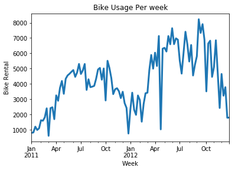

```python
bike['cnt'].asfreq('W').plot(linewidth = 3)
plt.title('Bike Usage Per week')
plt.xlabel('Week')
plt.ylabel('Bike Rental')
```

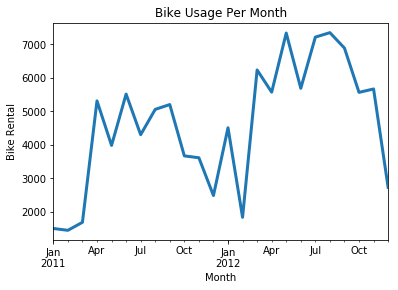

```python
bike['cnt'].asfreq('M').plot(linewidth = 3)
plt.title('Bike Usage Per Month')
plt.xlabel('Month')
plt.ylabel('Bike Rental')
```

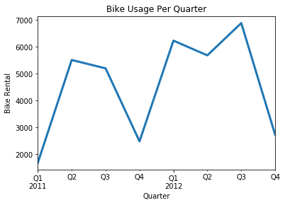

```python
bike['cnt'].asfreq('Q').plot(linewidth = 3)
plt.title('Bike Usage Per Quarter')
plt.xlabel('Quarter')
plt.ylabel('Bike Rental')
```

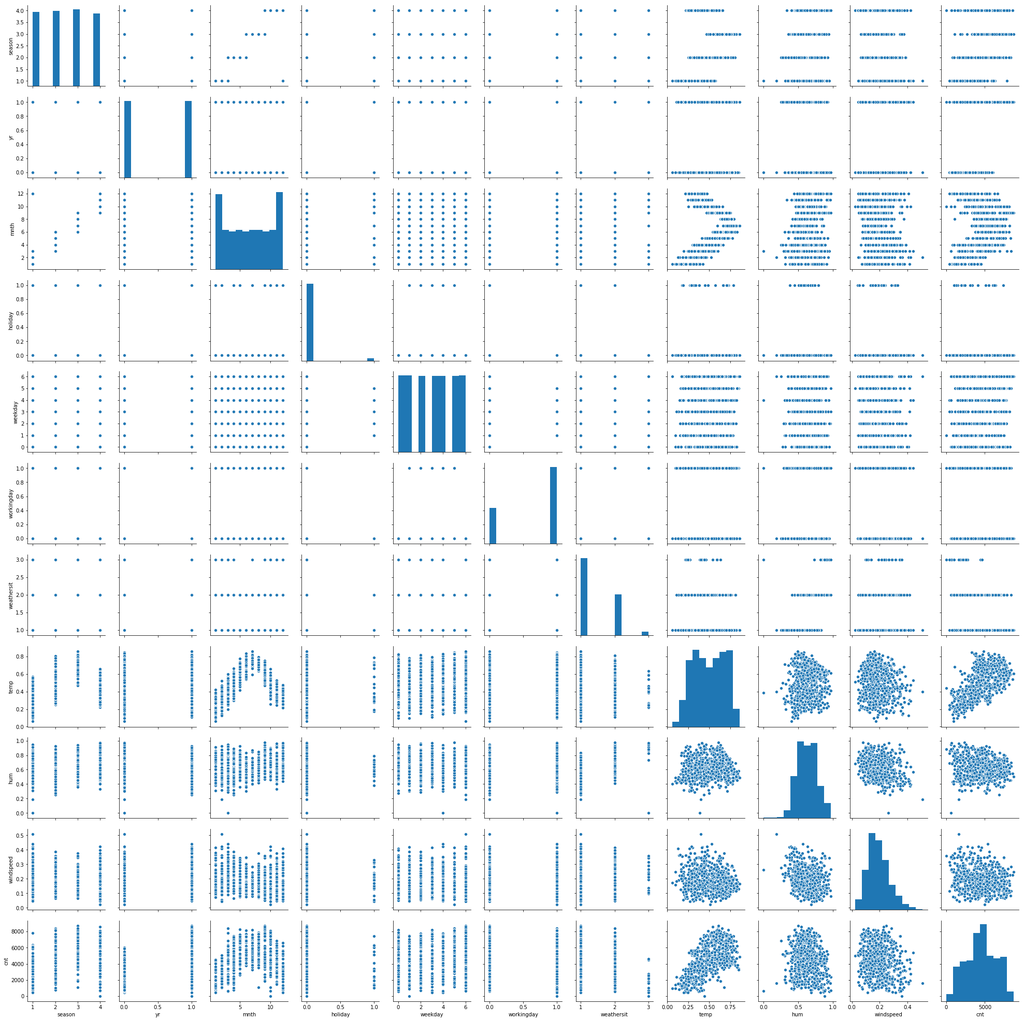

```python
sns.pairplot(bike)
```

```python
X_numerical = bike[['temp', 'hum', 'windspeed', 'cnt']]
```

```python
X_numerical
```

| dteday | temp | hum | windspeed | cnt |
| --- | --- | --- | --- | --- |
| 2011-01-01 | 0.344167 | 0.805833 | 0.160446 | 985 |
| 2011-01-02 | 0.363478 | 0.696087 | 0.248539 | 801 |
| 2011-01-03 | 0.196364 | 0.437273 | 0.248309 | 1349 |
| 2011-01-04 | 0.200000 | 0.590435 | 0.160296 | 1562 |
| 2011-01-05 | 0.226957 | 0.436957 | 0.186900 | 1600 |
| 2011-01-06 | 0.204348 | 0.518261 | 0.089565 | 1606 |
| 2011-01-07 | 0.196522 | 0.498696 | 0.168726 | 1510 |
| 2011-01-08 | 0.165000 | 0.535833 | 0.266804 | 959 |
| 2011-01-09 | 0.138333 | 0.434167 | 0.361950 | 822 |
| 2011-01-10 | 0.150833 | 0.482917 | 0.223267 | 1321 |
| 2011-01-11 | 0.169091 | 0.686364 | 0.122132 | 1263 |
| 2011-01-12 | 0.172727 | 0.599545 | 0.304627 | 1162 |
| 2011-01-13 | 0.165000 | 0.470417 | 0.301000 | 1406 |
| 2011-01-14 | 0.160870 | 0.537826 | 0.126548 | 1421 |
| 2011-01-15 | 0.233333 | 0.498750 | 0.157963 | 1248 |
| 2011-01-16 | 0.231667 | 0.483750 | 0.188433 | 1204 |
| 2011-01-17 | 0.175833 | 0.537500 | 0.194017 | 1000 |
| 2011-01-18 | 0.216667 | 0.861667 | 0.146775 | 683 |
| 2011-01-19 | 0.292174 | 0.741739 | 0.208317 | 1650 |
| 2011-01-20 | 0.261667 | 0.538333 | 0.195904 | 1927 |
| 2011-01-21 | 0.177500 | 0.457083 | 0.353242 | 1543 |
| 2011-01-22 | 0.059130 | 0.400000 | 0.171970 | 981 |
| 2011-01-23 | 0.096522 | 0.436522 | 0.246600 | 986 |
| 2011-01-24 | 0.097391 | 0.491739 | 0.158330 | 1416 |
| 2011-01-25 | 0.223478 | 0.616957 | 0.129796 | 1985 |
| 2011-01-26 | 0.217500 | 0.862500 | 0.293850 | 506 |
| 2011-01-27 | 0.195000 | 0.687500 | 0.113837 | 431 |
| 2011-01-28 | 0.203478 | 0.793043 | 0.123300 | 1167 |
| 2011-01-29 | 0.196522 | 0.651739 | 0.145365 | 1098 |
| 2011-01-30 | 0.216522 | 0.722174 | 0.073983 | 1096 |
| ... | ... | ... | ... | ... |
| 2012-12-02 | 0.347500 | 0.823333 | 0.124379 | 4649 |
| 2012-12-03 | 0.452500 | 0.767500 | 0.082721 | 6234 |
| 2012-12-04 | 0.475833 | 0.733750 | 0.174129 | 6606 |
| 2012-12-05 | 0.438333 | 0.485000 | 0.324021 | 5729 |
| 2012-12-06 | 0.255833 | 0.508750 | 0.174754 | 5375 |
| 2012-12-07 | 0.320833 | 0.764167 | 0.130600 | 5008 |
| 2012-12-08 | 0.381667 | 0.911250 | 0.101379 | 5582 |
| 2012-12-09 | 0.384167 | 0.905417 | 0.157975 | 3228 |
| 2012-12-10 | 0.435833 | 0.925000 | 0.190308 | 5170 |
| 2012-12-11 | 0.353333 | 0.596667 | 0.296037 | 5501 |
| 2012-12-12 | 0.297500 | 0.538333 | 0.162937 | 5319 |
| 2012-12-13 | 0.295833 | 0.485833 | 0.174129 | 5532 |
| 2012-12-14 | 0.281667 | 0.642917 | 0.131229 | 5611 |
| 2012-12-15 | 0.324167 | 0.650417 | 0.106350 | 5047 |
| 2012-12-16 | 0.362500 | 0.838750 | 0.100742 | 3786 |
| 2012-12-17 | 0.393333 | 0.907083 | 0.098258 | 4585 |
| 2012-12-18 | 0.410833 | 0.666250 | 0.221404 | 5557 |
| 2012-12-19 | 0.332500 | 0.625417 | 0.184092 | 5267 |
| 2012-12-20 | 0.330000 | 0.667917 | 0.132463 | 4128 |
| 2012-12-21 | 0.326667 | 0.556667 | 0.374383 | 3623 |
| 2012-12-22 | 0.265833 | 0.441250 | 0.407346 | 1749 |
| 2012-12-23 | 0.245833 | 0.515417 | 0.133083 | 1787 |
| 2012-12-24 | 0.231304 | 0.791304 | 0.077230 | 920 |
| 2012-12-25 | 0.291304 | 0.734783 | 0.168726 | 1013 |
| 2012-12-26 | 0.243333 | 0.823333 | 0.316546 | 441 |
| 2012-12-27 | 0.254167 | 0.652917 | 0.350133 | 2114 |
| 2012-12-28 | 0.253333 | 0.590000 | 0.155471 | 3095 |
| 2012-12-29 | 0.253333 | 0.752917 | 0.124383 | 1341 |
| 2012-12-30 | 0.255833 | 0.483333 | 0.350754 | 1796 |
| 2012-12-31 | 0.215833 | 0.577500 | 0.154846 | 2729 |

731 rows × 4 columns

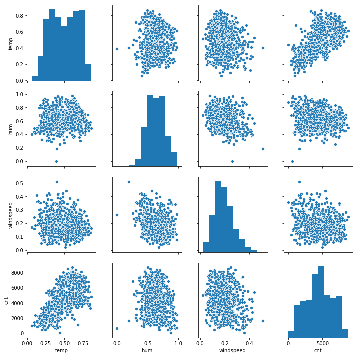

```python
sns.pairplot(X_numerical)
```

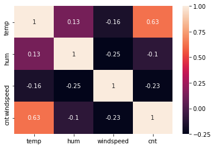

```python
sns.heatmap(X_numerical.corr(), annot =True)
```

# CREATE TRAINING AND TESTING DATASET

```python
X_cat = bike[['season', 'yr', 'mnth', 'holiday', 'weekday', 'workingday', 'weathersit']]
```

```python
X_cat
```

| dteday | season | yr | mnth | holiday | weekday | workingday | weathersit |
| --- | --- | --- | --- | --- | --- | --- | --- |
| 2011-01-01 | 1 | 0 | 1 | 0 | 6 | 0 | 2 |
| 2011-01-02 | 1 | 0 | 1 | 0 | 0 | 0 | 2 |
| 2011-01-03 | 1 | 0 | 1 | 0 | 1 | 1 | 1 |
| 2011-01-04 | 1 | 0 | 1 | 0 | 2 | 1 | 1 |
| 2011-01-05 | 1 | 0 | 1 | 0 | 3 | 1 | 1 |
| 2011-01-06 | 1 | 0 | 1 | 0 | 4 | 1 | 1 |
| 2011-01-07 | 1 | 0 | 1 | 0 | 5 | 1 | 2 |
| 2011-01-08 | 1 | 0 | 1 | 0 | 6 | 0 | 2 |
| 2011-01-09 | 1 | 0 | 1 | 0 | 0 | 0 | 1 |
| 2011-01-10 | 1 | 0 | 1 | 0 | 1 | 1 | 1 |
| 2011-01-11 | 1 | 0 | 1 | 0 | 2 | 1 | 2 |
| 2011-01-12 | 1 | 0 | 1 | 0 | 3 | 1 | 1 |
| 2011-01-13 | 1 | 0 | 1 | 0 | 4 | 1 | 1 |
| 2011-01-14 | 1 | 0 | 1 | 0 | 5 | 1 | 1 |
| 2011-01-15 | 1 | 0 | 1 | 0 | 6 | 0 | 2 |
| 2011-01-16 | 1 | 0 | 1 | 0 | 0 | 0 | 1 |
| 2011-01-17 | 1 | 0 | 1 | 1 | 1 | 0 | 2 |
| 2011-01-18 | 1 | 0 | 1 | 0 | 2 | 1 | 2 |
| 2011-01-19 | 1 | 0 | 1 | 0 | 3 | 1 | 2 |
| 2011-01-20 | 1 | 0 | 1 | 0 | 4 | 1 | 2 |
| 2011-01-21 | 1 | 0 | 1 | 0 | 5 | 1 | 1 |
| 2011-01-22 | 1 | 0 | 1 | 0 | 6 | 0 | 1 |
| 2011-01-23 | 1 | 0 | 1 | 0 | 0 | 0 | 1 |
| 2011-01-24 | 1 | 0 | 1 | 0 | 1 | 1 | 1 |
| 2011-01-25 | 1 | 0 | 1 | 0 | 2 | 1 | 2 |
| 2011-01-26 | 1 | 0 | 1 | 0 | 3 | 1 | 3 |
| 2011-01-27 | 1 | 0 | 1 | 0 | 4 | 1 | 1 |
| 2011-01-28 | 1 | 0 | 1 | 0 | 5 | 1 | 2 |
| 2011-01-29 | 1 | 0 | 1 | 0 | 6 | 0 | 1 |
| 2011-01-30 | 1 | 0 | 1 | 0 | 0 | 0 | 1 |
| ... | ... | ... | ... | ... | ... | ... | ... |
| 2012-12-02 | 4 | 1 | 12 | 0 | 0 | 0 | 2 |
| 2012-12-03 | 4 | 1 | 12 | 0 | 1 | 1 | 1 |
| 2012-12-04 | 4 | 1 | 12 | 0 | 2 | 1 | 1 |
| 2012-12-05 | 4 | 1 | 12 | 0 | 3 | 1 | 1 |
| 2012-12-06 | 4 | 1 | 12 | 0 | 4 | 1 | 1 |
| 2012-12-07 | 4 | 1 | 12 | 0 | 5 | 1 | 2 |
| 2012-12-08 | 4 | 1 | 12 | 0 | 6 | 0 | 2 |
| 2012-12-09 | 4 | 1 | 12 | 0 | 0 | 0 | 2 |
| 2012-12-10 | 4 | 1 | 12 | 0 | 1 | 1 | 2 |
| 2012-12-11 | 4 | 1 | 12 | 0 | 2 | 1 | 2 |
| 2012-12-12 | 4 | 1 | 12 | 0 | 3 | 1 | 2 |
| 2012-12-13 | 4 | 1 | 12 | 0 | 4 | 1 | 1 |
| 2012-12-14 | 4 | 1 | 12 | 0 | 5 | 1 | 1 |
| 2012-12-15 | 4 | 1 | 12 | 0 | 6 | 0 | 1 |
| 2012-12-16 | 4 | 1 | 12 | 0 | 0 | 0 | 2 |
| 2012-12-17 | 4 | 1 | 12 | 0 | 1 | 1 | 2 |
| 2012-12-18 | 4 | 1 | 12 | 0 | 2 | 1 | 1 |
| 2012-12-19 | 4 | 1 | 12 | 0 | 3 | 1 | 1 |
| 2012-12-20 | 4 | 1 | 12 | 0 | 4 | 1 | 2 |
| 2012-12-21 | 1 | 1 | 12 | 0 | 5 | 1 | 2 |
| 2012-12-22 | 1 | 1 | 12 | 0 | 6 | 0 | 1 |
| 2012-12-23 | 1 | 1 | 12 | 0 | 0 | 0 | 1 |
| 2012-12-24 | 1 | 1 | 12 | 0 | 1 | 1 | 2 |
| 2012-12-25 | 1 | 1 | 12 | 1 | 2 | 0 | 2 |
| 2012-12-26 | 1 | 1 | 12 | 0 | 3 | 1 | 3 |
| 2012-12-27 | 1 | 1 | 12 | 0 | 4 | 1 | 2 |
| 2012-12-28 | 1 | 1 | 12 | 0 | 5 | 1 | 2 |
| 2012-12-29 | 1 | 1 | 12 | 0 | 6 | 0 | 2 |
| 2012-12-30 | 1 | 1 | 12 | 0 | 0 | 0 | 1 |
| 2012-12-31 | 1 | 1 | 12 | 0 | 1 | 1 | 2 |

731 rows × 7 columns

```python
from sklearn.preprocessing import OneHotEncoder
onehotencoder = OneHotEncoder()
X_cat = onehotencoder.fit_transform(X_cat).toarray()
```

```python
X_cat.shape
```

```
(731, 32)
```

```python
X_cat = pd.DataFrame(X_cat)
```

```python
X_numerical
```

| dteday | temp | hum | windspeed | cnt |
| --- | --- | --- | --- | --- |
| 2011-01-01 | 0.344167 | 0.805833 | 0.160446 | 985 |
| 2011-01-02 | 0.363478 | 0.696087 | 0.248539 | 801 |
| 2011-01-03 | 0.196364 | 0.437273 | 0.248309 | 1349 |
| 2011-01-04 | 0.200000 | 0.590435 | 0.160296 | 1562 |
| 2011-01-05 | 0.226957 | 0.436957 | 0.186900 | 1600 |
| 2011-01-06 | 0.204348 | 0.518261 | 0.089565 | 1606 |
| 2011-01-07 | 0.196522 | 0.498696 | 0.168726 | 1510 |
| 2011-01-08 | 0.165000 | 0.535833 | 0.266804 | 959 |
| 2011-01-09 | 0.138333 | 0.434167 | 0.361950 | 822 |
| 2011-01-10 | 0.150833 | 0.482917 | 0.223267 | 1321 |
| 2011-01-11 | 0.169091 | 0.686364 | 0.122132 | 1263 |
| 2011-01-12 | 0.172727 | 0.599545 | 0.304627 | 1162 |
| 2011-01-13 | 0.165000 | 0.470417 | 0.301000 | 1406 |
| 2011-01-14 | 0.160870 | 0.537826 | 0.126548 | 1421 |
| 2011-01-15 | 0.233333 | 0.498750 | 0.157963 | 1248 |
| 2011-01-16 | 0.231667 | 0.483750 | 0.188433 | 1204 |
| 2011-01-17 | 0.175833 | 0.537500 | 0.194017 | 1000 |
| 2011-01-18 | 0.216667 | 0.861667 | 0.146775 | 683 |
| 2011-01-19 | 0.292174 | 0.741739 | 0.208317 | 1650 |
| 2011-01-20 | 0.261667 | 0.538333 | 0.195904 | 1927 |
| 2011-01-21 | 0.177500 | 0.457083 | 0.353242 | 1543 |
| 2011-01-22 | 0.059130 | 0.400000 | 0.171970 | 981 |
| 2011-01-23 | 0.096522 | 0.436522 | 0.246600 | 986 |
| 2011-01-24 | 0.097391 | 0.491739 | 0.158330 | 1416 |
| 2011-01-25 | 0.223478 | 0.616957 | 0.129796 | 1985 |
| 2011-01-26 | 0.217500 | 0.862500 | 0.293850 | 506 |
| 2011-01-27 | 0.195000 | 0.687500 | 0.113837 | 431 |
| 2011-01-28 | 0.203478 | 0.793043 | 0.123300 | 1167 |
| 2011-01-29 | 0.196522 | 0.651739 | 0.145365 | 1098 |
| 2011-01-30 | 0.216522 | 0.722174 | 0.073983 | 1096 |
| ... | ... | ... | ... | ... |
| 2012-12-02 | 0.347500 | 0.823333 | 0.124379 | 4649 |
| 2012-12-03 | 0.452500 | 0.767500 | 0.082721 | 6234 |
| 2012-12-04 | 0.475833 | 0.733750 | 0.174129 | 6606 |
| 2012-12-05 | 0.438333 | 0.485000 | 0.324021 | 5729 |
| 2012-12-06 | 0.255833 | 0.508750 | 0.174754 | 5375 |
| 2012-12-07 | 0.320833 | 0.764167 | 0.130600 | 5008 |
| 2012-12-08 | 0.381667 | 0.911250 | 0.101379 | 5582 |
| 2012-12-09 | 0.384167 | 0.905417 | 0.157975 | 3228 |
| 2012-12-10 | 0.435833 | 0.925000 | 0.190308 | 5170 |
| 2012-12-11 | 0.353333 | 0.596667 | 0.296037 | 5501 |
| 2012-12-12 | 0.297500 | 0.538333 | 0.162937 | 5319 |
| 2012-12-13 | 0.295833 | 0.485833 | 0.174129 | 5532 |
| 2012-12-14 | 0.281667 | 0.642917 | 0.131229 | 5611 |
| 2012-12-15 | 0.324167 | 0.650417 | 0.106350 | 5047 |
| 2012-12-16 | 0.362500 | 0.838750 | 0.100742 | 3786 |
| 2012-12-17 | 0.393333 | 0.907083 | 0.098258 | 4585 |
| 2012-12-18 | 0.410833 | 0.666250 | 0.221404 | 5557 |
| 2012-12-19 | 0.332500 | 0.625417 | 0.184092 | 5267 |
| 2012-12-20 | 0.330000 | 0.667917 | 0.132463 | 4128 |
| 2012-12-21 | 0.326667 | 0.556667 | 0.374383 | 3623 |
| 2012-12-22 | 0.265833 | 0.441250 | 0.407346 | 1749 |
| 2012-12-23 | 0.245833 | 0.515417 | 0.133083 | 1787 |
| 2012-12-24 | 0.231304 | 0.791304 | 0.077230 | 920 |
| 2012-12-25 | 0.291304 | 0.734783 | 0.168726 | 1013 |
| 2012-12-26 | 0.243333 | 0.823333 | 0.316546 | 441 |
| 2012-12-27 | 0.254167 | 0.652917 | 0.350133 | 2114 |
| 2012-12-28 | 0.253333 | 0.590000 | 0.155471 | 3095 |
| 2012-12-29 | 0.253333 | 0.752917 | 0.124383 | 1341 |
| 2012-12-30 | 0.255833 | 0.483333 | 0.350754 | 1796 |
| 2012-12-31 | 0.215833 | 0.577500 | 0.154846 | 2729 |

731 rows × 4 columns

```python
X_numerical = X_numerical.reset_index()
```

```python
X_all = pd.concat([X_cat, X_numerical], axis = 1)
```

```python
X_all
```

|  | 0 | 1 | 2 | 3 | 4 | 5 | 6 | 7 | 8 | 9 | 10 | 11 | 12 | 13 | 14 | 15 | 16 | 17 | 18 | 19 | 20 | 21 | 22 | 23 | 24 | 25 | 26 | 27 | 28 | … |
| --- | --- | --- | --- | --- | --- | --- | --- | --- | --- | --- | --- | --- | --- | --- | --- | --- | --- | --- | --- | --- | --- | --- | --- | --- | --- | --- | --- | --- | --- | --- |
| 0 | 1.0 | 0.0 | 0.0 | 0.0 | 1.0 | 0.0 | 1.0 | 0.0 | 0.0 | 0.0 | 0.0 | 0.0 | 0.0 | 0.0 | 0.0 | 0.0 | 0.0 | 0.0 | 1.0 | 0.0 | 0.0 | 0.0 | 0.0 | 0.0 | 0.0 | 0.0 | 1.0 | 1.0 | 0.0 | … |
| 1 | 1.0 | 0.0 | 0.0 | 0.0 | 1.0 | 0.0 | 1.0 | 0.0 | 0.0 | 0.0 | 0.0 | 0.0 | 0.0 | 0.0 | 0.0 | 0.0 | 0.0 | 0.0 | 1.0 | 0.0 | 1.0 | 0.0 | 0.0 | 0.0 | 0.0 | 0.0 | 0.0 | 1.0 | 0.0 | … |
| 2 | 1.0 | 0.0 | 0.0 | 0.0 | 1.0 | 0.0 | 1.0 | 0.0 | 0.0 | 0.0 | 0.0 | 0.0 | 0.0 | 0.0 | 0.0 | 0.0 | 0.0 | 0.0 | 1.0 | 0.0 | 0.0 | 1.0 | 0.0 | 0.0 | 0.0 | 0.0 | 0.0 | 0.0 | 1.0 | … |
| 3 | 1.0 | 0.0 | 0.0 | 0.0 | 1.0 | 0.0 | 1.0 | 0.0 | 0.0 | 0.0 | 0.0 | 0.0 | 0.0 | 0.0 | 0.0 | 0.0 | 0.0 | 0.0 | 1.0 | 0.0 | 0.0 | 0.0 | 1.0 | 0.0 | 0.0 | 0.0 | 0.0 | 0.0 | 1.0 | … |
| 4 | 1.0 | 0.0 | 0.0 | 0.0 | 1.0 | 0.0 | 1.0 | 0.0 | 0.0 | 0.0 | 0.0 | 0.0 | 0.0 | 0.0 | 0.0 | 0.0 | 0.0 | 0.0 | 1.0 | 0.0 | 0.0 | 0.0 | 0.0 | 1.0 | 0.0 | 0.0 | 0.0 | 0.0 | 1.0 | … |
| 5 | 1.0 | 0.0 | 0.0 | 0.0 | 1.0 | 0.0 | 1.0 | 0.0 | 0.0 | 0.0 | 0.0 | 0.0 | 0.0 | 0.0 | 0.0 | 0.0 | 0.0 | 0.0 | 1.0 | 0.0 | 0.0 | 0.0 | 0.0 | 0.0 | 1.0 | 0.0 | 0.0 | 0.0 | 1.0 | … |
| 6 | 1.0 | 0.0 | 0.0 | 0.0 | 1.0 | 0.0 | 1.0 | 0.0 | 0.0 | 0.0 | 0.0 | 0.0 | 0.0 | 0.0 | 0.0 | 0.0 | 0.0 | 0.0 | 1.0 | 0.0 | 0.0 | 0.0 | 0.0 | 0.0 | 0.0 | 1.0 | 0.0 | 0.0 | 1.0 | … |
| 7 | 1.0 | 0.0 | 0.0 | 0.0 | 1.0 | 0.0 | 1.0 | 0.0 | 0.0 | 0.0 | 0.0 | 0.0 | 0.0 | 0.0 | 0.0 | 0.0 | 0.0 | 0.0 | 1.0 | 0.0 | 0.0 | 0.0 | 0.0 | 0.0 | 0.0 | 0.0 | 1.0 | 1.0 | 0.0 | … |
| 8 | 1.0 | 0.0 | 0.0 | 0.0 | 1.0 | 0.0 | 1.0 | 0.0 | 0.0 | 0.0 | 0.0 | 0.0 | 0.0 | 0.0 | 0.0 | 0.0 | 0.0 | 0.0 | 1.0 | 0.0 | 1.0 | 0.0 | 0.0 | 0.0 | 0.0 | 0.0 | 0.0 | 1.0 | 0.0 | … |
| 9 | 1.0 | 0.0 | 0.0 | 0.0 | 1.0 | 0.0 | 1.0 | 0.0 | 0.0 | 0.0 | 0.0 | 0.0 | 0.0 | 0.0 | 0.0 | 0.0 | 0.0 | 0.0 | 1.0 | 0.0 | 0.0 | 1.0 | 0.0 | 0.0 | 0.0 | 0.0 | 0.0 | 0.0 | 1.0 | … |
| 10 | 1.0 | 0.0 | 0.0 | 0.0 | 1.0 | 0.0 | 1.0 | 0.0 | 0.0 | 0.0 | 0.0 | 0.0 | 0.0 | 0.0 | 0.0 | 0.0 | 0.0 | 0.0 | 1.0 | 0.0 | 0.0 | 0.0 | 1.0 | 0.0 | 0.0 | 0.0 | 0.0 | 0.0 | 1.0 | … |
| 11 | 1.0 | 0.0 | 0.0 | 0.0 | 1.0 | 0.0 | 1.0 | 0.0 | 0.0 | 0.0 | 0.0 | 0.0 | 0.0 | 0.0 | 0.0 | 0.0 | 0.0 | 0.0 | 1.0 | 0.0 | 0.0 | 0.0 | 0.0 | 1.0 | 0.0 | 0.0 | 0.0 | 0.0 | 1.0 | … |
| 12 | 1.0 | 0.0 | 0.0 | 0.0 | 1.0 | 0.0 | 1.0 | 0.0 | 0.0 | 0.0 | 0.0 | 0.0 | 0.0 | 0.0 | 0.0 | 0.0 | 0.0 | 0.0 | 1.0 | 0.0 | 0.0 | 0.0 | 0.0 | 0.0 | 1.0 | 0.0 | 0.0 | 0.0 | 1.0 | … |
| 13 | 1.0 | 0.0 | 0.0 | 0.0 | 1.0 | 0.0 | 1.0 | 0.0 | 0.0 | 0.0 | 0.0 | 0.0 | 0.0 | 0.0 | 0.0 | 0.0 | 0.0 | 0.0 | 1.0 | 0.0 | 0.0 | 0.0 | 0.0 | 0.0 | 0.0 | 1.0 | 0.0 | 0.0 | 1.0 | … |
| 14 | 1.0 | 0.0 | 0.0 | 0.0 | 1.0 | 0.0 | 1.0 | 0.0 | 0.0 | 0.0 | 0.0 | 0.0 | 0.0 | 0.0 | 0.0 | 0.0 | 0.0 | 0.0 | 1.0 | 0.0 | 0.0 | 0.0 | 0.0 | 0.0 | 0.0 | 0.0 | 1.0 | 1.0 | 0.0 | … |
| 15 | 1.0 | 0.0 | 0.0 | 0.0 | 1.0 | 0.0 | 1.0 | 0.0 | 0.0 | 0.0 | 0.0 | 0.0 | 0.0 | 0.0 | 0.0 | 0.0 | 0.0 | 0.0 | 1.0 | 0.0 | 1.0 | 0.0 | 0.0 | 0.0 | 0.0 | 0.0 | 0.0 | 1.0 | 0.0 | … |
| 16 | 1.0 | 0.0 | 0.0 | 0.0 | 1.0 | 0.0 | 1.0 | 0.0 | 0.0 | 0.0 | 0.0 | 0.0 | 0.0 | 0.0 | 0.0 | 0.0 | 0.0 | 0.0 | 0.0 | 1.0 | 0.0 | 1.0 | 0.0 | 0.0 | 0.0 | 0.0 | 0.0 | 1.0 | 0.0 | … |
| 17 | 1.0 | 0.0 | 0.0 | 0.0 | 1.0 | 0.0 | 1.0 | 0.0 | 0.0 | 0.0 | 0.0 | 0.0 | 0.0 | 0.0 | 0.0 | 0.0 | 0.0 | 0.0 | 1.0 | 0.0 | 0.0 | 0.0 | 1.0 | 0.0 | 0.0 | 0.0 | 0.0 | 0.0 | 1.0 | … |
| 18 | 1.0 | 0.0 | 0.0 | 0.0 | 1.0 | 0.0 | 1.0 | 0.0 | 0.0 | 0.0 | 0.0 | 0.0 | 0.0 | 0.0 | 0.0 | 0.0 | 0.0 | 0.0 | 1.0 | 0.0 | 0.0 | 0.0 | 0.0 | 1.0 | 0.0 | 0.0 | 0.0 | 0.0 | 1.0 | … |
| 19 | 1.0 | 0.0 | 0.0 | 0.0 | 1.0 | 0.0 | 1.0 | 0.0 | 0.0 | 0.0 | 0.0 | 0.0 | 0.0 | 0.0 | 0.0 | 0.0 | 0.0 | 0.0 | 1.0 | 0.0 | 0.0 | 0.0 | 0.0 | 0.0 | 1.0 | 0.0 | 0.0 | 0.0 | 1.0 | … |
| 20 | 1.0 | 0.0 | 0.0 | 0.0 | 1.0 | 0.0 | 1.0 | 0.0 | 0.0 | 0.0 | 0.0 | 0.0 | 0.0 | 0.0 | 0.0 | 0.0 | 0.0 | 0.0 | 1.0 | 0.0 | 0.0 | 0.0 | 0.0 | 0.0 | 0.0 | 1.0 | 0.0 | 0.0 | 1.0 | … |
| 21 | 1.0 | 0.0 | 0.0 | 0.0 | 1.0 | 0.0 | 1.0 | 0.0 | 0.0 | 0.0 | 0.0 | 0.0 | 0.0 | 0.0 | 0.0 | 0.0 | 0.0 | 0.0 | 1.0 | 0.0 | 0.0 | 0.0 | 0.0 | 0.0 | 0.0 | 0.0 | 1.0 | 1.0 | 0.0 | … |
| 22 | 1.0 | 0.0 | 0.0 | 0.0 | 1.0 | 0.0 | 1.0 | 0.0 | 0.0 | 0.0 | 0.0 | 0.0 | 0.0 | 0.0 | 0.0 | 0.0 | 0.0 | 0.0 | 1.0 | 0.0 | 1.0 | 0.0 | 0.0 | 0.0 | 0.0 | 0.0 | 0.0 | 1.0 | 0.0 | … |
| 23 | 1.0 | 0.0 | 0.0 | 0.0 | 1.0 | 0.0 | 1.0 | 0.0 | 0.0 | 0.0 | 0.0 | 0.0 | 0.0 | 0.0 | 0.0 | 0.0 | 0.0 | 0.0 | 1.0 | 0.0 | 0.0 | 1.0 | 0.0 | 0.0 | 0.0 | 0.0 | 0.0 | 0.0 | 1.0 | … |
| 24 | 1.0 | 0.0 | 0.0 | 0.0 | 1.0 | 0.0 | 1.0 | 0.0 | 0.0 | 0.0 | 0.0 | 0.0 | 0.0 | 0.0 | 0.0 | 0.0 | 0.0 | 0.0 | 1.0 | 0.0 | 0.0 | 0.0 | 1.0 | 0.0 | 0.0 | 0.0 | 0.0 | 0.0 | 1.0 | … |
| 25 | 1.0 | 0.0 | 0.0 | 0.0 | 1.0 | 0.0 | 1.0 | 0.0 | 0.0 | 0.0 | 0.0 | 0.0 | 0.0 | 0.0 | 0.0 | 0.0 | 0.0 | 0.0 | 1.0 | 0.0 | 0.0 | 0.0 | 0.0 | 1.0 | 0.0 | 0.0 | 0.0 | 0.0 | 1.0 | … |
| 26 | 1.0 | 0.0 | 0.0 | 0.0 | 1.0 | 0.0 | 1.0 | 0.0 | 0.0 | 0.0 | 0.0 | 0.0 | 0.0 | 0.0 | 0.0 | 0.0 | 0.0 | 0.0 | 1.0 | 0.0 | 0.0 | 0.0 | 0.0 | 0.0 | 1.0 | 0.0 | 0.0 | 0.0 | 1.0 | … |
| 27 | 1.0 | 0.0 | 0.0 | 0.0 | 1.0 | 0.0 | 1.0 | 0.0 | 0.0 | 0.0 | 0.0 | 0.0 | 0.0 | 0.0 | 0.0 | 0.0 | 0.0 | 0.0 | 1.0 | 0.0 | 0.0 | 0.0 | 0.0 | 0.0 | 0.0 | 1.0 | 0.0 | 0.0 | 1.0 | … |
| 28 | 1.0 | 0.0 | 0.0 | 0.0 | 1.0 | 0.0 | 1.0 | 0.0 | 0.0 | 0.0 | 0.0 | 0.0 | 0.0 | 0.0 | 0.0 | 0.0 | 0.0 | 0.0 | 1.0 | 0.0 | 0.0 | 0.0 | 0.0 | 0.0 | 0.0 | 0.0 | 1.0 | 1.0 | 0.0 | … |
| 29 | 1.0 | 0.0 | 0.0 | 0.0 | 1.0 | 0.0 | 1.0 | 0.0 | 0.0 | 0.0 | 0.0 | 0.0 | 0.0 | 0.0 | 0.0 | 0.0 | 0.0 | 0.0 | 1.0 | 0.0 | 1.0 | 0.0 | 0.0 | 0.0 | 0.0 | 0.0 | 0.0 | 1.0 | 0.0 | … |
| ... | ... | ... | ... | ... | ... | ... | ... | ... | ... | ... | ... | ... | ... | ... | ... | ... | ... | ... | ... | ... | ... | ... | ... | ... | ... | ... | ... | ... | ... | … |
| 701 | 0.0 | 0.0 | 0.0 | 1.0 | 0.0 | 1.0 | 0.0 | 0.0 | 0.0 | 0.0 | 0.0 | 0.0 | 0.0 | 0.0 | 0.0 | 0.0 | 0.0 | 1.0 | 1.0 | 0.0 | 1.0 | 0.0 | 0.0 | 0.0 | 0.0 | 0.0 | 0.0 | 1.0 | 0.0 | … |
| 702 | 0.0 | 0.0 | 0.0 | 1.0 | 0.0 | 1.0 | 0.0 | 0.0 | 0.0 | 0.0 | 0.0 | 0.0 | 0.0 | 0.0 | 0.0 | 0.0 | 0.0 | 1.0 | 1.0 | 0.0 | 0.0 | 1.0 | 0.0 | 0.0 | 0.0 | 0.0 | 0.0 | 0.0 | 1.0 | … |
| 703 | 0.0 | 0.0 | 0.0 | 1.0 | 0.0 | 1.0 | 0.0 | 0.0 | 0.0 | 0.0 | 0.0 | 0.0 | 0.0 | 0.0 | 0.0 | 0.0 | 0.0 | 1.0 | 1.0 | 0.0 | 0.0 | 0.0 | 1.0 | 0.0 | 0.0 | 0.0 | 0.0 | 0.0 | 1.0 | … |
| 704 | 0.0 | 0.0 | 0.0 | 1.0 | 0.0 | 1.0 | 0.0 | 0.0 | 0.0 | 0.0 | 0.0 | 0.0 | 0.0 | 0.0 | 0.0 | 0.0 | 0.0 | 1.0 | 1.0 | 0.0 | 0.0 | 0.0 | 0.0 | 1.0 | 0.0 | 0.0 | 0.0 | 0.0 | 1.0 | … |
| 705 | 0.0 | 0.0 | 0.0 | 1.0 | 0.0 | 1.0 | 0.0 | 0.0 | 0.0 | 0.0 | 0.0 | 0.0 | 0.0 | 0.0 | 0.0 | 0.0 | 0.0 | 1.0 | 1.0 | 0.0 | 0.0 | 0.0 | 0.0 | 0.0 | 1.0 | 0.0 | 0.0 | 0.0 | 1.0 | … |
| 706 | 0.0 | 0.0 | 0.0 | 1.0 | 0.0 | 1.0 | 0.0 | 0.0 | 0.0 | 0.0 | 0.0 | 0.0 | 0.0 | 0.0 | 0.0 | 0.0 | 0.0 | 1.0 | 1.0 | 0.0 | 0.0 | 0.0 | 0.0 | 0.0 | 0.0 | 1.0 | 0.0 | 0.0 | 1.0 | … |
| 707 | 0.0 | 0.0 | 0.0 | 1.0 | 0.0 | 1.0 | 0.0 | 0.0 | 0.0 | 0.0 | 0.0 | 0.0 | 0.0 | 0.0 | 0.0 | 0.0 | 0.0 | 1.0 | 1.0 | 0.0 | 0.0 | 0.0 | 0.0 | 0.0 | 0.0 | 0.0 | 1.0 | 1.0 | 0.0 | … |
| 708 | 0.0 | 0.0 | 0.0 | 1.0 | 0.0 | 1.0 | 0.0 | 0.0 | 0.0 | 0.0 | 0.0 | 0.0 | 0.0 | 0.0 | 0.0 | 0.0 | 0.0 | 1.0 | 1.0 | 0.0 | 1.0 | 0.0 | 0.0 | 0.0 | 0.0 | 0.0 | 0.0 | 1.0 | 0.0 | … |
| 709 | 0.0 | 0.0 | 0.0 | 1.0 | 0.0 | 1.0 | 0.0 | 0.0 | 0.0 | 0.0 | 0.0 | 0.0 | 0.0 | 0.0 | 0.0 | 0.0 | 0.0 | 1.0 | 1.0 | 0.0 | 0.0 | 1.0 | 0.0 | 0.0 | 0.0 | 0.0 | 0.0 | 0.0 | 1.0 | … |
| 710 | 0.0 | 0.0 | 0.0 | 1.0 | 0.0 | 1.0 | 0.0 | 0.0 | 0.0 | 0.0 | 0.0 | 0.0 | 0.0 | 0.0 | 0.0 | 0.0 | 0.0 | 1.0 | 1.0 | 0.0 | 0.0 | 0.0 | 1.0 | 0.0 | 0.0 | 0.0 | 0.0 | 0.0 | 1.0 | … |
| 711 | 0.0 | 0.0 | 0.0 | 1.0 | 0.0 | 1.0 | 0.0 | 0.0 | 0.0 | 0.0 | 0.0 | 0.0 | 0.0 | 0.0 | 0.0 | 0.0 | 0.0 | 1.0 | 1.0 | 0.0 | 0.0 | 0.0 | 0.0 | 1.0 | 0.0 | 0.0 | 0.0 | 0.0 | 1.0 | … |
| 712 | 0.0 | 0.0 | 0.0 | 1.0 | 0.0 | 1.0 | 0.0 | 0.0 | 0.0 | 0.0 | 0.0 | 0.0 | 0.0 | 0.0 | 0.0 | 0.0 | 0.0 | 1.0 | 1.0 | 0.0 | 0.0 | 0.0 | 0.0 | 0.0 | 1.0 | 0.0 | 0.0 | 0.0 | 1.0 | … |
| 713 | 0.0 | 0.0 | 0.0 | 1.0 | 0.0 | 1.0 | 0.0 | 0.0 | 0.0 | 0.0 | 0.0 | 0.0 | 0.0 | 0.0 | 0.0 | 0.0 | 0.0 | 1.0 | 1.0 | 0.0 | 0.0 | 0.0 | 0.0 | 0.0 | 0.0 | 1.0 | 0.0 | 0.0 | 1.0 | … |
| 714 | 0.0 | 0.0 | 0.0 | 1.0 | 0.0 | 1.0 | 0.0 | 0.0 | 0.0 | 0.0 | 0.0 | 0.0 | 0.0 | 0.0 | 0.0 | 0.0 | 0.0 | 1.0 | 1.0 | 0.0 | 0.0 | 0.0 | 0.0 | 0.0 | 0.0 | 0.0 | 1.0 | 1.0 | 0.0 | … |
| 715 | 0.0 | 0.0 | 0.0 | 1.0 | 0.0 | 1.0 | 0.0 | 0.0 | 0.0 | 0.0 | 0.0 | 0.0 | 0.0 | 0.0 | 0.0 | 0.0 | 0.0 | 1.0 | 1.0 | 0.0 | 1.0 | 0.0 | 0.0 | 0.0 | 0.0 | 0.0 | 0.0 | 1.0 | 0.0 | … |
| 716 | 0.0 | 0.0 | 0.0 | 1.0 | 0.0 | 1.0 | 0.0 | 0.0 | 0.0 | 0.0 | 0.0 | 0.0 | 0.0 | 0.0 | 0.0 | 0.0 | 0.0 | 1.0 | 1.0 | 0.0 | 0.0 | 1.0 | 0.0 | 0.0 | 0.0 | 0.0 | 0.0 | 0.0 | 1.0 | … |
| 717 | 0.0 | 0.0 | 0.0 | 1.0 | 0.0 | 1.0 | 0.0 | 0.0 | 0.0 | 0.0 | 0.0 | 0.0 | 0.0 | 0.0 | 0.0 | 0.0 | 0.0 | 1.0 | 1.0 | 0.0 | 0.0 | 0.0 | 1.0 | 0.0 | 0.0 | 0.0 | 0.0 | 0.0 | 1.0 | … |
| 718 | 0.0 | 0.0 | 0.0 | 1.0 | 0.0 | 1.0 | 0.0 | 0.0 | 0.0 | 0.0 | 0.0 | 0.0 | 0.0 | 0.0 | 0.0 | 0.0 | 0.0 | 1.0 | 1.0 | 0.0 | 0.0 | 0.0 | 0.0 | 1.0 | 0.0 | 0.0 | 0.0 | 0.0 | 1.0 | … |
| 719 | 0.0 | 0.0 | 0.0 | 1.0 | 0.0 | 1.0 | 0.0 | 0.0 | 0.0 | 0.0 | 0.0 | 0.0 | 0.0 | 0.0 | 0.0 | 0.0 | 0.0 | 1.0 | 1.0 | 0.0 | 0.0 | 0.0 | 0.0 | 0.0 | 1.0 | 0.0 | 0.0 | 0.0 | 1.0 | … |
| 720 | 1.0 | 0.0 | 0.0 | 0.0 | 0.0 | 1.0 | 0.0 | 0.0 | 0.0 | 0.0 | 0.0 | 0.0 | 0.0 | 0.0 | 0.0 | 0.0 | 0.0 | 1.0 | 1.0 | 0.0 | 0.0 | 0.0 | 0.0 | 0.0 | 0.0 | 1.0 | 0.0 | 0.0 | 1.0 | … |
| 721 | 1.0 | 0.0 | 0.0 | 0.0 | 0.0 | 1.0 | 0.0 | 0.0 | 0.0 | 0.0 | 0.0 | 0.0 | 0.0 | 0.0 | 0.0 | 0.0 | 0.0 | 1.0 | 1.0 | 0.0 | 0.0 | 0.0 | 0.0 | 0.0 | 0.0 | 0.0 | 1.0 | 1.0 | 0.0 | … |
| 722 | 1.0 | 0.0 | 0.0 | 0.0 | 0.0 | 1.0 | 0.0 | 0.0 | 0.0 | 0.0 | 0.0 | 0.0 | 0.0 | 0.0 | 0.0 | 0.0 | 0.0 | 1.0 | 1.0 | 0.0 | 1.0 | 0.0 | 0.0 | 0.0 | 0.0 | 0.0 | 0.0 | 1.0 | 0.0 | … |
| 723 | 1.0 | 0.0 | 0.0 | 0.0 | 0.0 | 1.0 | 0.0 | 0.0 | 0.0 | 0.0 | 0.0 | 0.0 | 0.0 | 0.0 | 0.0 | 0.0 | 0.0 | 1.0 | 1.0 | 0.0 | 0.0 | 1.0 | 0.0 | 0.0 | 0.0 | 0.0 | 0.0 | 0.0 | 1.0 | … |
| 724 | 1.0 | 0.0 | 0.0 | 0.0 | 0.0 | 1.0 | 0.0 | 0.0 | 0.0 | 0.0 | 0.0 | 0.0 | 0.0 | 0.0 | 0.0 | 0.0 | 0.0 | 1.0 | 0.0 | 1.0 | 0.0 | 0.0 | 1.0 | 0.0 | 0.0 | 0.0 | 0.0 | 1.0 | 0.0 | … |
| 725 | 1.0 | 0.0 | 0.0 | 0.0 | 0.0 | 1.0 | 0.0 | 0.0 | 0.0 | 0.0 | 0.0 | 0.0 | 0.0 | 0.0 | 0.0 | 0.0 | 0.0 | 1.0 | 1.0 | 0.0 | 0.0 | 0.0 | 0.0 | 1.0 | 0.0 | 0.0 | 0.0 | 0.0 | 1.0 | … |
| 726 | 1.0 | 0.0 | 0.0 | 0.0 | 0.0 | 1.0 | 0.0 | 0.0 | 0.0 | 0.0 | 0.0 | 0.0 | 0.0 | 0.0 | 0.0 | 0.0 | 0.0 | 1.0 | 1.0 | 0.0 | 0.0 | 0.0 | 0.0 | 0.0 | 1.0 | 0.0 | 0.0 | 0.0 | 1.0 | … |
| 727 | 1.0 | 0.0 | 0.0 | 0.0 | 0.0 | 1.0 | 0.0 | 0.0 | 0.0 | 0.0 | 0.0 | 0.0 | 0.0 | 0.0 | 0.0 | 0.0 | 0.0 | 1.0 | 1.0 | 0.0 | 0.0 | 0.0 | 0.0 | 0.0 | 0.0 | 1.0 | 0.0 | 0.0 | 1.0 | … |
| 728 | 1.0 | 0.0 | 0.0 | 0.0 | 0.0 | 1.0 | 0.0 | 0.0 | 0.0 | 0.0 | 0.0 | 0.0 | 0.0 | 0.0 | 0.0 | 0.0 | 0.0 | 1.0 | 1.0 | 0.0 | 0.0 | 0.0 | 0.0 | 0.0 | 0.0 | 0.0 | 1.0 | 1.0 | 0.0 | … |
| 729 | 1.0 | 0.0 | 0.0 | 0.0 | 0.0 | 1.0 | 0.0 | 0.0 | 0.0 | 0.0 | 0.0 | 0.0 | 0.0 | 0.0 | 0.0 | 0.0 | 0.0 | 1.0 | 1.0 | 0.0 | 1.0 | 0.0 | 0.0 | 0.0 | 0.0 | 0.0 | 0.0 | 1.0 | 0.0 | … |
| 730 | 1.0 | 0.0 | 0.0 | 0.0 | 0.0 | 1.0 | 0.0 | 0.0 | 0.0 | 0.0 | 0.0 | 0.0 | 0.0 | 0.0 | 0.0 | 0.0 | 0.0 | 1.0 | 1.0 | 0.0 | 0.0 | 1.0 | 0.0 | 0.0 | 0.0 | 0.0 | 0.0 | 0.0 | 1.0 | … |

731 rows × 37 columns

```python
X_all = X_all.drop('dteday', axis = 1)
```

```python
X_all
```

|  | 0 | 1 | 2 | 3 | 4 | 5 | 6 | 7 | 8 | 9 | 10 | 11 | 12 | 13 | 14 | 15 | 16 | 17 | 18 | 19 | 20 | 21 | 22 | 23 | 24 | 25 | 26 | 27 | 28 | … |
| --- | --- | --- | --- | --- | --- | --- | --- | --- | --- | --- | --- | --- | --- | --- | --- | --- | --- | --- | --- | --- | --- | --- | --- | --- | --- | --- | --- | --- | --- | --- |
| 0 | 1.0 | 0.0 | 0.0 | 0.0 | 1.0 | 0.0 | 1.0 | 0.0 | 0.0 | 0.0 | 0.0 | 0.0 | 0.0 | 0.0 | 0.0 | 0.0 | 0.0 | 0.0 | 1.0 | 0.0 | 0.0 | 0.0 | 0.0 | 0.0 | 0.0 | 0.0 | 1.0 | 1.0 | 0.0 | … |
| 1 | 1.0 | 0.0 | 0.0 | 0.0 | 1.0 | 0.0 | 1.0 | 0.0 | 0.0 | 0.0 | 0.0 | 0.0 | 0.0 | 0.0 | 0.0 | 0.0 | 0.0 | 0.0 | 1.0 | 0.0 | 1.0 | 0.0 | 0.0 | 0.0 | 0.0 | 0.0 | 0.0 | 1.0 | 0.0 | … |
| 2 | 1.0 | 0.0 | 0.0 | 0.0 | 1.0 | 0.0 | 1.0 | 0.0 | 0.0 | 0.0 | 0.0 | 0.0 | 0.0 | 0.0 | 0.0 | 0.0 | 0.0 | 0.0 | 1.0 | 0.0 | 0.0 | 1.0 | 0.0 | 0.0 | 0.0 | 0.0 | 0.0 | 0.0 | 1.0 | … |
| 3 | 1.0 | 0.0 | 0.0 | 0.0 | 1.0 | 0.0 | 1.0 | 0.0 | 0.0 | 0.0 | 0.0 | 0.0 | 0.0 | 0.0 | 0.0 | 0.0 | 0.0 | 0.0 | 1.0 | 0.0 | 0.0 | 0.0 | 1.0 | 0.0 | 0.0 | 0.0 | 0.0 | 0.0 | 1.0 | … |
| 4 | 1.0 | 0.0 | 0.0 | 0.0 | 1.0 | 0.0 | 1.0 | 0.0 | 0.0 | 0.0 | 0.0 | 0.0 | 0.0 | 0.0 | 0.0 | 0.0 | 0.0 | 0.0 | 1.0 | 0.0 | 0.0 | 0.0 | 0.0 | 1.0 | 0.0 | 0.0 | 0.0 | 0.0 | 1.0 | … |
| 5 | 1.0 | 0.0 | 0.0 | 0.0 | 1.0 | 0.0 | 1.0 | 0.0 | 0.0 | 0.0 | 0.0 | 0.0 | 0.0 | 0.0 | 0.0 | 0.0 | 0.0 | 0.0 | 1.0 | 0.0 | 0.0 | 0.0 | 0.0 | 0.0 | 1.0 | 0.0 | 0.0 | 0.0 | 1.0 | … |
| 6 | 1.0 | 0.0 | 0.0 | 0.0 | 1.0 | 0.0 | 1.0 | 0.0 | 0.0 | 0.0 | 0.0 | 0.0 | 0.0 | 0.0 | 0.0 | 0.0 | 0.0 | 0.0 | 1.0 | 0.0 | 0.0 | 0.0 | 0.0 | 0.0 | 0.0 | 1.0 | 0.0 | 0.0 | 1.0 | … |
| 7 | 1.0 | 0.0 | 0.0 | 0.0 | 1.0 | 0.0 | 1.0 | 0.0 | 0.0 | 0.0 | 0.0 | 0.0 | 0.0 | 0.0 | 0.0 | 0.0 | 0.0 | 0.0 | 1.0 | 0.0 | 0.0 | 0.0 | 0.0 | 0.0 | 0.0 | 0.0 | 1.0 | 1.0 | 0.0 | … |
| 8 | 1.0 | 0.0 | 0.0 | 0.0 | 1.0 | 0.0 | 1.0 | 0.0 | 0.0 | 0.0 | 0.0 | 0.0 | 0.0 | 0.0 | 0.0 | 0.0 | 0.0 | 0.0 | 1.0 | 0.0 | 1.0 | 0.0 | 0.0 | 0.0 | 0.0 | 0.0 | 0.0 | 1.0 | 0.0 | … |
| 9 | 1.0 | 0.0 | 0.0 | 0.0 | 1.0 | 0.0 | 1.0 | 0.0 | 0.0 | 0.0 | 0.0 | 0.0 | 0.0 | 0.0 | 0.0 | 0.0 | 0.0 | 0.0 | 1.0 | 0.0 | 0.0 | 1.0 | 0.0 | 0.0 | 0.0 | 0.0 | 0.0 | 0.0 | 1.0 | … |
| 10 | 1.0 | 0.0 | 0.0 | 0.0 | 1.0 | 0.0 | 1.0 | 0.0 | 0.0 | 0.0 | 0.0 | 0.0 | 0.0 | 0.0 | 0.0 | 0.0 | 0.0 | 0.0 | 1.0 | 0.0 | 0.0 | 0.0 | 1.0 | 0.0 | 0.0 | 0.0 | 0.0 | 0.0 | 1.0 | … |
| 11 | 1.0 | 0.0 | 0.0 | 0.0 | 1.0 | 0.0 | 1.0 | 0.0 | 0.0 | 0.0 | 0.0 | 0.0 | 0.0 | 0.0 | 0.0 | 0.0 | 0.0 | 0.0 | 1.0 | 0.0 | 0.0 | 0.0 | 0.0 | 1.0 | 0.0 | 0.0 | 0.0 | 0.0 | 1.0 | … |
| 12 | 1.0 | 0.0 | 0.0 | 0.0 | 1.0 | 0.0 | 1.0 | 0.0 | 0.0 | 0.0 | 0.0 | 0.0 | 0.0 | 0.0 | 0.0 | 0.0 | 0.0 | 0.0 | 1.0 | 0.0 | 0.0 | 0.0 | 0.0 | 0.0 | 1.0 | 0.0 | 0.0 | 0.0 | 1.0 | … |
| 13 | 1.0 | 0.0 | 0.0 | 0.0 | 1.0 | 0.0 | 1.0 | 0.0 | 0.0 | 0.0 | 0.0 | 0.0 | 0.0 | 0.0 | 0.0 | 0.0 | 0.0 | 0.0 | 1.0 | 0.0 | 0.0 | 0.0 | 0.0 | 0.0 | 0.0 | 1.0 | 0.0 | 0.0 | 1.0 | … |
| 14 | 1.0 | 0.0 | 0.0 | 0.0 | 1.0 | 0.0 | 1.0 | 0.0 | 0.0 | 0.0 | 0.0 | 0.0 | 0.0 | 0.0 | 0.0 | 0.0 | 0.0 | 0.0 | 1.0 | 0.0 | 0.0 | 0.0 | 0.0 | 0.0 | 0.0 | 0.0 | 1.0 | 1.0 | 0.0 | … |
| 15 | 1.0 | 0.0 | 0.0 | 0.0 | 1.0 | 0.0 | 1.0 | 0.0 | 0.0 | 0.0 | 0.0 | 0.0 | 0.0 | 0.0 | 0.0 | 0.0 | 0.0 | 0.0 | 1.0 | 0.0 | 1.0 | 0.0 | 0.0 | 0.0 | 0.0 | 0.0 | 0.0 | 1.0 | 0.0 | … |
| 16 | 1.0 | 0.0 | 0.0 | 0.0 | 1.0 | 0.0 | 1.0 | 0.0 | 0.0 | 0.0 | 0.0 | 0.0 | 0.0 | 0.0 | 0.0 | 0.0 | 0.0 | 0.0 | 0.0 | 1.0 | 0.0 | 1.0 | 0.0 | 0.0 | 0.0 | 0.0 | 0.0 | 1.0 | 0.0 | … |
| 17 | 1.0 | 0.0 | 0.0 | 0.0 | 1.0 | 0.0 | 1.0 | 0.0 | 0.0 | 0.0 | 0.0 | 0.0 | 0.0 | 0.0 | 0.0 | 0.0 | 0.0 | 0.0 | 1.0 | 0.0 | 0.0 | 0.0 | 1.0 | 0.0 | 0.0 | 0.0 | 0.0 | 0.0 | 1.0 | … |
| 18 | 1.0 | 0.0 | 0.0 | 0.0 | 1.0 | 0.0 | 1.0 | 0.0 | 0.0 | 0.0 | 0.0 | 0.0 | 0.0 | 0.0 | 0.0 | 0.0 | 0.0 | 0.0 | 1.0 | 0.0 | 0.0 | 0.0 | 0.0 | 1.0 | 0.0 | 0.0 | 0.0 | 0.0 | 1.0 | … |
| 19 | 1.0 | 0.0 | 0.0 | 0.0 | 1.0 | 0.0 | 1.0 | 0.0 | 0.0 | 0.0 | 0.0 | 0.0 | 0.0 | 0.0 | 0.0 | 0.0 | 0.0 | 0.0 | 1.0 | 0.0 | 0.0 | 0.0 | 0.0 | 0.0 | 1.0 | 0.0 | 0.0 | 0.0 | 1.0 | … |
| 20 | 1.0 | 0.0 | 0.0 | 0.0 | 1.0 | 0.0 | 1.0 | 0.0 | 0.0 | 0.0 | 0.0 | 0.0 | 0.0 | 0.0 | 0.0 | 0.0 | 0.0 | 0.0 | 1.0 | 0.0 | 0.0 | 0.0 | 0.0 | 0.0 | 0.0 | 1.0 | 0.0 | 0.0 | 1.0 | … |
| 21 | 1.0 | 0.0 | 0.0 | 0.0 | 1.0 | 0.0 | 1.0 | 0.0 | 0.0 | 0.0 | 0.0 | 0.0 | 0.0 | 0.0 | 0.0 | 0.0 | 0.0 | 0.0 | 1.0 | 0.0 | 0.0 | 0.0 | 0.0 | 0.0 | 0.0 | 0.0 | 1.0 | 1.0 | 0.0 | … |
| 22 | 1.0 | 0.0 | 0.0 | 0.0 | 1.0 | 0.0 | 1.0 | 0.0 | 0.0 | 0.0 | 0.0 | 0.0 | 0.0 | 0.0 | 0.0 | 0.0 | 0.0 | 0.0 | 1.0 | 0.0 | 1.0 | 0.0 | 0.0 | 0.0 | 0.0 | 0.0 | 0.0 | 1.0 | 0.0 | … |
| 23 | 1.0 | 0.0 | 0.0 | 0.0 | 1.0 | 0.0 | 1.0 | 0.0 | 0.0 | 0.0 | 0.0 | 0.0 | 0.0 | 0.0 | 0.0 | 0.0 | 0.0 | 0.0 | 1.0 | 0.0 | 0.0 | 1.0 | 0.0 | 0.0 | 0.0 | 0.0 | 0.0 | 0.0 | 1.0 | … |
| 24 | 1.0 | 0.0 | 0.0 | 0.0 | 1.0 | 0.0 | 1.0 | 0.0 | 0.0 | 0.0 | 0.0 | 0.0 | 0.0 | 0.0 | 0.0 | 0.0 | 0.0 | 0.0 | 1.0 | 0.0 | 0.0 | 0.0 | 1.0 | 0.0 | 0.0 | 0.0 | 0.0 | 0.0 | 1.0 | … |
| 25 | 1.0 | 0.0 | 0.0 | 0.0 | 1.0 | 0.0 | 1.0 | 0.0 | 0.0 | 0.0 | 0.0 | 0.0 | 0.0 | 0.0 | 0.0 | 0.0 | 0.0 | 0.0 | 1.0 | 0.0 | 0.0 | 0.0 | 0.0 | 1.0 | 0.0 | 0.0 | 0.0 | 0.0 | 1.0 | … |
| 26 | 1.0 | 0.0 | 0.0 | 0.0 | 1.0 | 0.0 | 1.0 | 0.0 | 0.0 | 0.0 | 0.0 | 0.0 | 0.0 | 0.0 | 0.0 | 0.0 | 0.0 | 0.0 | 1.0 | 0.0 | 0.0 | 0.0 | 0.0 | 0.0 | 1.0 | 0.0 | 0.0 | 0.0 | 1.0 | … |
| 27 | 1.0 | 0.0 | 0.0 | 0.0 | 1.0 | 0.0 | 1.0 | 0.0 | 0.0 | 0.0 | 0.0 | 0.0 | 0.0 | 0.0 | 0.0 | 0.0 | 0.0 | 0.0 | 1.0 | 0.0 | 0.0 | 0.0 | 0.0 | 0.0 | 0.0 | 1.0 | 0.0 | 0.0 | 1.0 | … |
| 28 | 1.0 | 0.0 | 0.0 | 0.0 | 1.0 | 0.0 | 1.0 | 0.0 | 0.0 | 0.0 | 0.0 | 0.0 | 0.0 | 0.0 | 0.0 | 0.0 | 0.0 | 0.0 | 1.0 | 0.0 | 0.0 | 0.0 | 0.0 | 0.0 | 0.0 | 0.0 | 1.0 | 1.0 | 0.0 | … |
| 29 | 1.0 | 0.0 | 0.0 | 0.0 | 1.0 | 0.0 | 1.0 | 0.0 | 0.0 | 0.0 | 0.0 | 0.0 | 0.0 | 0.0 | 0.0 | 0.0 | 0.0 | 0.0 | 1.0 | 0.0 | 1.0 | 0.0 | 0.0 | 0.0 | 0.0 | 0.0 | 0.0 | 1.0 | 0.0 | … |
| ... | ... | ... | ... | ... | ... | ... | ... | ... | ... | ... | ... | ... | ... | ... | ... | ... | ... | ... | ... | ... | ... | ... | ... | ... | ... | ... | ... | ... | ... | … |
| 701 | 0.0 | 0.0 | 0.0 | 1.0 | 0.0 | 1.0 | 0.0 | 0.0 | 0.0 | 0.0 | 0.0 | 0.0 | 0.0 | 0.0 | 0.0 | 0.0 | 0.0 | 1.0 | 1.0 | 0.0 | 1.0 | 0.0 | 0.0 | 0.0 | 0.0 | 0.0 | 0.0 | 1.0 | 0.0 | … |
| 702 | 0.0 | 0.0 | 0.0 | 1.0 | 0.0 | 1.0 | 0.0 | 0.0 | 0.0 | 0.0 | 0.0 | 0.0 | 0.0 | 0.0 | 0.0 | 0.0 | 0.0 | 1.0 | 1.0 | 0.0 | 0.0 | 1.0 | 0.0 | 0.0 | 0.0 | 0.0 | 0.0 | 0.0 | 1.0 | … |
| 703 | 0.0 | 0.0 | 0.0 | 1.0 | 0.0 | 1.0 | 0.0 | 0.0 | 0.0 | 0.0 | 0.0 | 0.0 | 0.0 | 0.0 | 0.0 | 0.0 | 0.0 | 1.0 | 1.0 | 0.0 | 0.0 | 0.0 | 1.0 | 0.0 | 0.0 | 0.0 | 0.0 | 0.0 | 1.0 | … |
| 704 | 0.0 | 0.0 | 0.0 | 1.0 | 0.0 | 1.0 | 0.0 | 0.0 | 0.0 | 0.0 | 0.0 | 0.0 | 0.0 | 0.0 | 0.0 | 0.0 | 0.0 | 1.0 | 1.0 | 0.0 | 0.0 | 0.0 | 0.0 | 1.0 | 0.0 | 0.0 | 0.0 | 0.0 | 1.0 | … |
| 705 | 0.0 | 0.0 | 0.0 | 1.0 | 0.0 | 1.0 | 0.0 | 0.0 | 0.0 | 0.0 | 0.0 | 0.0 | 0.0 | 0.0 | 0.0 | 0.0 | 0.0 | 1.0 | 1.0 | 0.0 | 0.0 | 0.0 | 0.0 | 0.0 | 1.0 | 0.0 | 0.0 | 0.0 | 1.0 | … |
| 706 | 0.0 | 0.0 | 0.0 | 1.0 | 0.0 | 1.0 | 0.0 | 0.0 | 0.0 | 0.0 | 0.0 | 0.0 | 0.0 | 0.0 | 0.0 | 0.0 | 0.0 | 1.0 | 1.0 | 0.0 | 0.0 | 0.0 | 0.0 | 0.0 | 0.0 | 1.0 | 0.0 | 0.0 | 1.0 | … |
| 707 | 0.0 | 0.0 | 0.0 | 1.0 | 0.0 | 1.0 | 0.0 | 0.0 | 0.0 | 0.0 | 0.0 | 0.0 | 0.0 | 0.0 | 0.0 | 0.0 | 0.0 | 1.0 | 1.0 | 0.0 | 0.0 | 0.0 | 0.0 | 0.0 | 0.0 | 0.0 | 1.0 | 1.0 | 0.0 | … |
| 708 | 0.0 | 0.0 | 0.0 | 1.0 | 0.0 | 1.0 | 0.0 | 0.0 | 0.0 | 0.0 | 0.0 | 0.0 | 0.0 | 0.0 | 0.0 | 0.0 | 0.0 | 1.0 | 1.0 | 0.0 | 1.0 | 0.0 | 0.0 | 0.0 | 0.0 | 0.0 | 0.0 | 1.0 | 0.0 | … |
| 709 | 0.0 | 0.0 | 0.0 | 1.0 | 0.0 | 1.0 | 0.0 | 0.0 | 0.0 | 0.0 | 0.0 | 0.0 | 0.0 | 0.0 | 0.0 | 0.0 | 0.0 | 1.0 | 1.0 | 0.0 | 0.0 | 1.0 | 0.0 | 0.0 | 0.0 | 0.0 | 0.0 | 0.0 | 1.0 | … |
| 710 | 0.0 | 0.0 | 0.0 | 1.0 | 0.0 | 1.0 | 0.0 | 0.0 | 0.0 | 0.0 | 0.0 | 0.0 | 0.0 | 0.0 | 0.0 | 0.0 | 0.0 | 1.0 | 1.0 | 0.0 | 0.0 | 0.0 | 1.0 | 0.0 | 0.0 | 0.0 | 0.0 | 0.0 | 1.0 | … |
| 711 | 0.0 | 0.0 | 0.0 | 1.0 | 0.0 | 1.0 | 0.0 | 0.0 | 0.0 | 0.0 | 0.0 | 0.0 | 0.0 | 0.0 | 0.0 | 0.0 | 0.0 | 1.0 | 1.0 | 0.0 | 0.0 | 0.0 | 0.0 | 1.0 | 0.0 | 0.0 | 0.0 | 0.0 | 1.0 | … |
| 712 | 0.0 | 0.0 | 0.0 | 1.0 | 0.0 | 1.0 | 0.0 | 0.0 | 0.0 | 0.0 | 0.0 | 0.0 | 0.0 | 0.0 | 0.0 | 0.0 | 0.0 | 1.0 | 1.0 | 0.0 | 0.0 | 0.0 | 0.0 | 0.0 | 1.0 | 0.0 | 0.0 | 0.0 | 1.0 | … |
| 713 | 0.0 | 0.0 | 0.0 | 1.0 | 0.0 | 1.0 | 0.0 | 0.0 | 0.0 | 0.0 | 0.0 | 0.0 | 0.0 | 0.0 | 0.0 | 0.0 | 0.0 | 1.0 | 1.0 | 0.0 | 0.0 | 0.0 | 0.0 | 0.0 | 0.0 | 1.0 | 0.0 | 0.0 | 1.0 | … |
| 714 | 0.0 | 0.0 | 0.0 | 1.0 | 0.0 | 1.0 | 0.0 | 0.0 | 0.0 | 0.0 | 0.0 | 0.0 | 0.0 | 0.0 | 0.0 | 0.0 | 0.0 | 1.0 | 1.0 | 0.0 | 0.0 | 0.0 | 0.0 | 0.0 | 0.0 | 0.0 | 1.0 | 1.0 | 0.0 | … |
| 715 | 0.0 | 0.0 | 0.0 | 1.0 | 0.0 | 1.0 | 0.0 | 0.0 | 0.0 | 0.0 | 0.0 | 0.0 | 0.0 | 0.0 | 0.0 | 0.0 | 0.0 | 1.0 | 1.0 | 0.0 | 1.0 | 0.0 | 0.0 | 0.0 | 0.0 | 0.0 | 0.0 | 1.0 | 0.0 | … |
| 716 | 0.0 | 0.0 | 0.0 | 1.0 | 0.0 | 1.0 | 0.0 | 0.0 | 0.0 | 0.0 | 0.0 | 0.0 | 0.0 | 0.0 | 0.0 | 0.0 | 0.0 | 1.0 | 1.0 | 0.0 | 0.0 | 1.0 | 0.0 | 0.0 | 0.0 | 0.0 | 0.0 | 0.0 | 1.0 | … |
| 717 | 0.0 | 0.0 | 0.0 | 1.0 | 0.0 | 1.0 | 0.0 | 0.0 | 0.0 | 0.0 | 0.0 | 0.0 | 0.0 | 0.0 | 0.0 | 0.0 | 0.0 | 1.0 | 1.0 | 0.0 | 0.0 | 0.0 | 1.0 | 0.0 | 0.0 | 0.0 | 0.0 | 0.0 | 1.0 | … |
| 718 | 0.0 | 0.0 | 0.0 | 1.0 | 0.0 | 1.0 | 0.0 | 0.0 | 0.0 | 0.0 | 0.0 | 0.0 | 0.0 | 0.0 | 0.0 | 0.0 | 0.0 | 1.0 | 1.0 | 0.0 | 0.0 | 0.0 | 0.0 | 1.0 | 0.0 | 0.0 | 0.0 | 0.0 | 1.0 | … |
| 719 | 0.0 | 0.0 | 0.0 | 1.0 | 0.0 | 1.0 | 0.0 | 0.0 | 0.0 | 0.0 | 0.0 | 0.0 | 0.0 | 0.0 | 0.0 | 0.0 | 0.0 | 1.0 | 1.0 | 0.0 | 0.0 | 0.0 | 0.0 | 0.0 | 1.0 | 0.0 | 0.0 | 0.0 | 1.0 | … |
| 720 | 1.0 | 0.0 | 0.0 | 0.0 | 0.0 | 1.0 | 0.0 | 0.0 | 0.0 | 0.0 | 0.0 | 0.0 | 0.0 | 0.0 | 0.0 | 0.0 | 0.0 | 1.0 | 1.0 | 0.0 | 0.0 | 0.0 | 0.0 | 0.0 | 0.0 | 1.0 | 0.0 | 0.0 | 1.0 | … |
| 721 | 1.0 | 0.0 | 0.0 | 0.0 | 0.0 | 1.0 | 0.0 | 0.0 | 0.0 | 0.0 | 0.0 | 0.0 | 0.0 | 0.0 | 0.0 | 0.0 | 0.0 | 1.0 | 1.0 | 0.0 | 0.0 | 0.0 | 0.0 | 0.0 | 0.0 | 0.0 | 1.0 | 1.0 | 0.0 | … |
| 722 | 1.0 | 0.0 | 0.0 | 0.0 | 0.0 | 1.0 | 0.0 | 0.0 | 0.0 | 0.0 | 0.0 | 0.0 | 0.0 | 0.0 | 0.0 | 0.0 | 0.0 | 1.0 | 1.0 | 0.0 | 1.0 | 0.0 | 0.0 | 0.0 | 0.0 | 0.0 | 0.0 | 1.0 | 0.0 | … |
| 723 | 1.0 | 0.0 | 0.0 | 0.0 | 0.0 | 1.0 | 0.0 | 0.0 | 0.0 | 0.0 | 0.0 | 0.0 | 0.0 | 0.0 | 0.0 | 0.0 | 0.0 | 1.0 | 1.0 | 0.0 | 0.0 | 1.0 | 0.0 | 0.0 | 0.0 | 0.0 | 0.0 | 0.0 | 1.0 | … |
| 724 | 1.0 | 0.0 | 0.0 | 0.0 | 0.0 | 1.0 | 0.0 | 0.0 | 0.0 | 0.0 | 0.0 | 0.0 | 0.0 | 0.0 | 0.0 | 0.0 | 0.0 | 1.0 | 0.0 | 1.0 | 0.0 | 0.0 | 1.0 | 0.0 | 0.0 | 0.0 | 0.0 | 1.0 | 0.0 | … |
| 725 | 1.0 | 0.0 | 0.0 | 0.0 | 0.0 | 1.0 | 0.0 | 0.0 | 0.0 | 0.0 | 0.0 | 0.0 | 0.0 | 0.0 | 0.0 | 0.0 | 0.0 | 1.0 | 1.0 | 0.0 | 0.0 | 0.0 | 0.0 | 1.0 | 0.0 | 0.0 | 0.0 | 0.0 | 1.0 | … |
| 726 | 1.0 | 0.0 | 0.0 | 0.0 | 0.0 | 1.0 | 0.0 | 0.0 | 0.0 | 0.0 | 0.0 | 0.0 | 0.0 | 0.0 | 0.0 | 0.0 | 0.0 | 1.0 | 1.0 | 0.0 | 0.0 | 0.0 | 0.0 | 0.0 | 1.0 | 0.0 | 0.0 | 0.0 | 1.0 | … |
| 727 | 1.0 | 0.0 | 0.0 | 0.0 | 0.0 | 1.0 | 0.0 | 0.0 | 0.0 | 0.0 | 0.0 | 0.0 | 0.0 | 0.0 | 0.0 | 0.0 | 0.0 | 1.0 | 1.0 | 0.0 | 0.0 | 0.0 | 0.0 | 0.0 | 0.0 | 1.0 | 0.0 | 0.0 | 1.0 | … |
| 728 | 1.0 | 0.0 | 0.0 | 0.0 | 0.0 | 1.0 | 0.0 | 0.0 | 0.0 | 0.0 | 0.0 | 0.0 | 0.0 | 0.0 | 0.0 | 0.0 | 0.0 | 1.0 | 1.0 | 0.0 | 0.0 | 0.0 | 0.0 | 0.0 | 0.0 | 0.0 | 1.0 | 1.0 | 0.0 | … |
| 729 | 1.0 | 0.0 | 0.0 | 0.0 | 0.0 | 1.0 | 0.0 | 0.0 | 0.0 | 0.0 | 0.0 | 0.0 | 0.0 | 0.0 | 0.0 | 0.0 | 0.0 | 1.0 | 1.0 | 0.0 | 1.0 | 0.0 | 0.0 | 0.0 | 0.0 | 0.0 | 0.0 | 1.0 | 0.0 | … |
| 730 | 1.0 | 0.0 | 0.0 | 0.0 | 0.0 | 1.0 | 0.0 | 0.0 | 0.0 | 0.0 | 0.0 | 0.0 | 0.0 | 0.0 | 0.0 | 0.0 | 0.0 | 1.0 | 1.0 | 0.0 | 0.0 | 1.0 | 0.0 | 0.0 | 0.0 | 0.0 | 0.0 | 0.0 | 1.0 | … |

731 rows × 36 columns

```python
X = X_all.iloc[:, :-1].values
y = X_all.iloc[:, -1:].values
```

```python
X.shape
```

```
(731, 35)
```

```python
y.shape
```

```
(731, 1)
```

```python
from sklearn.preprocessing import MinMaxScaler
scaler = MinMaxScaler()
y = scaler.fit_transform(y)
```

```python
from sklearn.model_selection import train_test_split
X_train, X_test, y_train, y_test = train_test_split(X, y, test_size = 0.2)
```

```python
X_train.shape
```

```
(584, 35)
```

```python
X_test.shape
```

```
(147, 35)
```

# TRAIN THE MODEL

```python
model = tf.keras.models.Sequential()
model.add(tf.keras.layers.Dense(units=100, activation='relu', input_shape=(35, )))
model.add(tf.keras.layers.Dense(units=100, activation='relu'))
model.add(tf.keras.layers.Dense(units=100, activation='relu'))
model.add(tf.keras.layers.Dense(units=1, activation='linear'))
```

```python
model.summary()
```

```
Model: "sequential"
_________________________________________________________________
Layer (type)                 Output Shape              Param #
=================================================================
dense (Dense)                (None, 100)               3600
_________________________________________________________________
dense_1 (Dense)              (None, 100)               10100
_________________________________________________________________
dense_2 (Dense)              (None, 100)               10100
_________________________________________________________________
dense_3 (Dense)              (None, 1)                 101
=================================================================
Total params: 23,901
Trainable params: 23,901
Non-trainable params: 0
_________________________________________________________________
```

```python
model.compile(optimizer='Adam', loss='mean_squared_error')
```

```python
epochs_hist = model.fit(X_train, y_train, epochs = 20, batch_size = 50, validation_split = 0.2)
```

```
Train on 467 samples, validate on 117 samples
```

# EVALUATE THE MODEL

```python
epochs_hist.history.keys()
```

```
dict_keys(['loss', 'val_loss'])
```

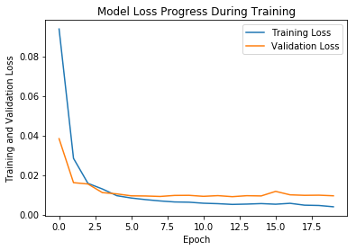

```python
plt.plot(epochs_hist.history['loss'])
plt.plot(epochs_hist.history['val_loss'])
plt.title('Model Loss Progress During Training')
plt.xlabel('Epoch')
plt.ylabel('Training and Validation Loss')
plt.legend(['Training Loss', 'Validation Loss'])
```

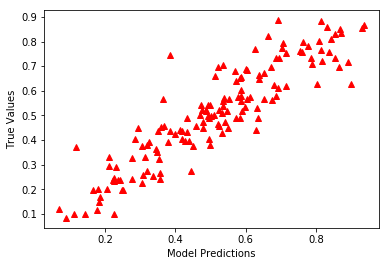

```python
y_predict = model.predict(X_test)
plt.plot(y_test, y_predict, "^", color = 'r')
plt.xlabel('Model Predictions')
plt.ylabel('True Values')
```

```python
y_predict_orig = scaler.inverse_transform(y_predict)
y_test_orig = scaler.inverse_transform(y_test)
```

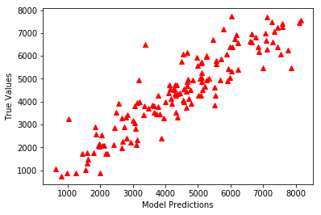

```python
plt.plot(y_test_orig, y_predict_orig, "^", color = 'r')
plt.xlabel('Model Predictions')
plt.ylabel('True Values')
```

```python
k = X_test.shape[1]
n = len(X_test)
n
```

```
147
```

```python
from sklearn.metrics import r2_score, mean_squared_error, mean_absolute_error
from math import sqrt

RMSE = float(format(np.sqrt(mean_squared_error(y_test_orig, y_predict_orig)),'.3f'))
MSE = mean_squared_error(y_test_orig, y_predict_orig)
MAE = mean_absolute_error(y_test_orig, y_predict_orig)
r2 = r2_score(y_test_orig, y_predict_orig)
adj_r2 = 1-(1-r2)*(n-1)/(n-k-1)

print('RMSE =',RMSE, '\nMSE =',MSE, '\nMAE =',MAE, '\nR2 =', r2, '\nAdjusted R2 =', adj_r2)
```

```
RMSE = 762.666
MSE = 581659.5822855905
MAE = 565.8806633981718
R2 = 0.8211374576134476
Adjusted R2 = 0.7647393586627329
```

# Skills covered:

- Regression
- Gradient Descent
- Back propogation
- Bias/Variance Trade-offs
- MSE
- MAE
- R-Squared
- Adjusted R-Squared
- Activation Functions
- Multilayer Perceptron Network
- ANN Training & Epochs

Useful resources:

- Understanding Machine Learning
- An Introduction to Statistical Learning